# YCHI5045M Introduction to Statistics for Health Scientists: Computer Sessions Notes & Exercises

# 1 Aim and objectives

The aim for these introductory statistics computer practical sessions is to help you develop some fundamental skills required to:

1. Calculate a sample size (i.e. plan how much data you need to collect)
2. Sample data robustly.
3. Analyse quantitative data.

However, we will cover aim 2) first followed by a mixture of aims 1) and 3), and most of our time will be spent on aim 3). In terms of analysing data, we will walk you through all stages from preparing a “raw” dataset to reporting and interpreting your results. To plan sample sizes we will use a user-friendly web-based sample size calculator, and to plan a robust sampling of data we will use Microsoft Excel, while to analyse data we will use a commonly used, comprehensive statistical software package called SPSS.

The key objectives for these sessions are for you to gain skills and experience in:

1. Calculating sample sizes necessary for common analyses.
2. Taking statistically robust “probability samples” from lists of sampling units (e.g. individuals).
3. Using the widely used and powerful SPSS statistical software package.
4. Cleaning, processing and preparing data for analysis.
5. Exploring, describing and visualising data.
6. Making inferences (generalisations) about data to answer research questions using a small but powerful range of statistical methods/analyses.
7. Correctly and meaningfully interpreting statistical results in terms of their implications for research questions/hypotheses.

# 2 Preliminary information

## 2.1 A word of encouragement if you want/need it!

Students often find learning and doing statistics to be hard, sometimes very hard! Unfortunately this is to be expected and there are no short-cuts or secrets. Unless you are a genius then like most people, including ourselves, to really begin to understand statistics more deeply and to be able to confidently and correctly analyse typical datasets independently will take a lot of time and effort. However, we firmly believe that it is perfectly possible for any motivated student to get to any level of skill and understanding they wish to reach if they are simply prepared to put in the necessary effort and practice, and the rewards can be huge. Being able to correctly run and interpret even simple statistical analyses gives you skills that are highly valuable in the world of research, and which are increasingly valuable and sought after in the wider world. So please don’t despair when things seem difficult or impossible. We’ve all felt that way, but like any new skill it really does gets easier and easier with practice, and it can even be enjoyable (no really, being able to take a dataset and generate insights about the world can be a really exciting and enjoyable process!).

## 2.2 About this handout

This handout is intended to serve as both a comprehensive guide to the introductory statistics computer practical sessions and as a longer-term reference document. In particular, you can refer to this document for guidance on your statistical analyses when you are completing the summative assessment for this module, and for your data collection and data analysis planning and activities during your dissertations/research projects, if they involve any quantitative analyses. You may feel it contains a lot of detail but actually it only covers the basics. However, we have tried carefully to only provide the key information necessary to carry out the statistical aspect of the most common types of quantitative research robustly, and we have tried to limit the display of information that you may not wish to view, at least straight away, by using buttons that can reveal or re-hide such information.

For all software exercises we provide step-by-step video-based and text-based instructions that are essentially identical about how to do everything, as well as occasionally using pictures to illustrate some things. So you can choose whether to watch a video or read some text to understand how to do everything, but there is no need to do both, although you may find the videos helpful at first to see what to do in the software and the text helpful as a reference for the future when understanding things like interpreting results.

Note: with the text instructions we refer to menus, tools, options (like tick boxes) and buttons etc in the different software packages using highlighted text like this.

**Please note that all SPSS instructions relate to SPSS version 27, which is the version that I have on my computer. This may not be the version that you are using either on a campus computer or your own computer. However, SPSS typically changes very little from version to version, especially when it comes to standard tools and analyses. So although things may look a little different for you there shouldn’t (hopefully) be any issues in following the instructions.**

## 2.3 How these sessions relate to the summative assignment

In summary: we do not expect you to use any methods other than those that we will cover in these sessions when analysing data for the summative assignment.

Please see the “YCHI5045M 20-21 Assignment Guidance.doc” document for full guidance on the summative assignment. This can be downloaded from Minerva. From the YCHI5045M module page under the *Assessment and Feedback* heading go to the *Assessment* page and look for the *Assignment Information* section.

However, in summary: for the summative assignment you will need to analyse a dataset on your own. Don’t panic! The analysis methods explained in this handout are completely sufficient to analyse the dataset provided for the summative assignment, and **we do not expect you to use any other methods than those taught in these sessions** for your summative assignment analyses. You can certainly use any other methods you already know, or subsequently learn if you wish. However, it is of course your responsibility to ensure you use them correctly and, just as importantly, to demonstrate that you have used them correctly by providing evidence that all relevant assumptions were met etc, otherwise you will fail to gain full marks.

Based on the methods/analyses you will learn in these sessions, it is up to you to decide which are most suitable for your summative assignment analyses given the research question and data provided in the summative assignment. Some methods may be simply less robust choices, and therefore produce results which may be accurate but will be more prone to bias, while other methods will not make sense (or even work) given the data and research question. Hopefully this should be clear though after these sessions.

There is therefore some flexibility in which methods you can use and you can certainly use any suitable methods, and you should consider the trade-off between using a more robust method vs a less robust method which you may be more comfortable with and less likely to make a mistake with. However, to gain the highest mark with whatever methods you use you must demonstrate a clear awareness of the limitations and risks of bias associated with those methods. This is particularly important if you choose to use simpler methods of analysis (e.g. t-tests instead of multiple linear regression).

# 3 Probability sampling

Sampling is the process whereby we choose which “units of observation” or “sampling units” within our target population we will collect data from. *Therefore, the first stage of sampling, which should always occur very early on in the research and study design process, is when you clearly and explicitly define your target population*. Units of observation are the “things” we are sampling to collect data from. These are usually individuals, typically patients or the public, but they can be anything such as schools, health facilities, villages, districts or even countries. See the sampling lecture for full details. However, in summary the only sampling methods that are guaranteed to produce unbiased results, albeit only on average or “in the long-run”, are “probability sampling” methods. This is because all standard statistical methods of analysis assume that sample data are randomly sampled from a given target population using some specific form of probability sampling. Therefore, the only way to robustly satisfy this assumption is clearly to take some form of probability sample.

To take a probability sample you require a sampling frame, which is just a list of all units of observation in the target population that you are aiming to generalise your results to (e.g. all individuals in a region, all primary care health facilities in a country etc). *Therefore, the second stage of any sampling process is to obtain or create a sampling frame for your target population*. Note: for a probability sampling method to be valid it must be possible, at least in theory although you wouldn’t actually do it in practice, to calculate each unit of observation’s probability of being selected, which may or may not be equal for all units, and should not be zero for any unit.

For most sampling methods we require a complete and comprehensive sampling frame before we actually sample. Although for some multi-stage sampling approaches, including those typically used by large-scale household surveys (as discussed in the lecture), you can use incomplete sampling frames to start your sampling and construct additional but still incomplete sampling frame(s) during your sampling process to achieve a robust probability sample. However, as these multi-stage approaches are quite complicated and you would not be advised to undertake them without extensive statistical support we will not practice them here.

In these sampling practical sessions we will therefore look at how you can apply most of the commonly used simple probability sampling methods, specifically simple random sampling, a stratified random sampling with *proportionate stratification* and *disproportionate stratification*, and systematic random sampling. We will assume we have a complete sampling frame for our hypothetical target population. We will also note how these methods can also be used to take single-stage cluster samples with complete second/final-stage sampling, and how they can be combined into multi-stage cluster samples. However, we will not actually practice these much more complicated methods as it’s very unlikely you would ever need to implement them yourself (unless you become a survey methodologist etc).

## 3.1 Non-probability sampling

While desirable it is clearly often not feasible to use probability sampling methods, usually because of the lack of a suitable sampling frame. For example, if you are studying patients attending a healthcare facility over a given period and you need to collect data on sampled patients *on the day they attend the facility* it’s typically impossible to construct a sampling frame because you won’t know who will be visiting each day! Therefore, you may often need to resort to non-probability sampling methods such as quota sampling or convenience sampling, and just try to make your samples as representative of your target population as you can, while minimising the opportunity for any researcher sampling bias.

Broadly speaking it is often more justifiable to generalise results from analytical (associational) studies that use non-probability sampling methods than from descriptive studies (surveys) that use non-probability sampling methods, and consequently if you are aiming to describe certain characteristics of a given target population you should aim to take a probability sample. However, you may often be able to make a good justification that results from an analytical study can be generalised despite the study using non-probability sampling methods. For example, many (maybe most) trials of patient-level treatments use non-probability samples, often convenience samples taken at health facilities as patients attend, due to the difficulty of taking a true probability sample. In such circumstances it is often justifiable to generalise the results to other individuals who share similar key characteristics with the trial sample (e.g. age, sex, and biomedical characteristics distributions), because patient-level treatments often work fairly similarly across different populations with similar characteristics. This may be much less justified for complex interventions delivered at higher levels, such as complex interventions with staff-level and facility-level components, because the effects of these types of interventions are likely to be much more dependent on the study’s context. Hence, generalising the results of complex interventions from studies like cluster trials that use non-probability samples may be much more questionable. The only “solution” is to think very carefully when planning your sampling methods and think explicitly from the start about who you want your results to robustly generalise to.

## 3.2 Simple random sampling

### 3.2.1 Overview

Simple random sampling involves taking a random sample of a given size from a sampling frame, which results in each unit of observation having an equal probability of being selected. You can take a simple random sample from a sampling frame in various ways, such as by generating random numbers that correspond to IDs that are pre-allocated to all units of observation, or you can do it by simply randomly sorting the list and just selecting the first n units of observation, where n is your sample size. We will use this second approach as it’s easy to implement in Excel.

### 3.2.2 Advantages of simple random sampling

- Easy to implement and explain.
- Requires minimal data on your target population units of observation: just a list of all units of observation, plus usually some way of identifying/contacting them once selected.

### 3.2.3 Disadvantages/limitations of simple random sampling

- Although simple random sampling guarantees that you will select a sample that is representative (i.e. unbiased) of your target population *on average/in the long-run*, i.e. over many hypothetically repeated samples, it is not the best approach at achieving this goal for any given sample, and obviously in practice you typically only ever take one sample! This is especially the case when the population is heterogeneous (highly varied in the characteristics/relationships of interest) and/or if sample size is small, say in the tens or low hundreds rather than the high hundreds or thousands (as the sample size increases the chances of getting an unrepresentative sample decrease). As these two situations are often true it is often better to use stratified random sampling instead, if possible.
- If your sampling units cover a large geographical area simple random sampling can produce a very logistically inefficient, costly, and geographically spread-out sample. See cluster sampling for an possible solution to this problem.

### 3.2.4 Scenario

You work for a district governmental health department and you have been tasked with assessing the capacity and service delivery characteristics of the public primary care facilities within your district. Specifically, you need to report the typical (e.g. mean/median) staffing levels (e.g. the no. drs and nurses), resources and equipment levels (e.g. no. beds, no. oxygen canisters, no. x-ray machines), and services delivery levels (e.g. the no. of deliveries with a skilled birth attendant during the last 6 months, the no. of under 5s receiving their full set of vaccinations during the last 6 months etc) for all public primary care facilities.

Our aim is therefore to take a simple random sample of 50 facilities from the list.

### 3.2.5 Exercise: taking a simple random sample using Excel

[Video: exercise: taking a simple random sample using Excel](https://youtu.be/GrHFm7VlNt4)

- Load the “Health facilities list - simple random sample.xlsx” Excel spreadsheet. You will see it has various self-explanatory columns/variables including “facility_name”, “facility_address”, and “facility_tel”.
- In column A (the blank column immediately to the left of the “facility_name” column) enter the following (or similar) word as a heading: random_no
- Immediately under this new column in cell A2 (the first row where the facility data starts) click on the cell and type =rand() and press enter. This Excel function generates a random number between 0 and 1 to six decimal places.
- Then simply ensure that cell A2 is selected (i.e. you’ve clicked on it) and then just double click on the small solid square at the very bottom right of this cell. This should copy and paste the function all the way down to the end of the facility data.
- Next click on the “random_no” column heading (cell A1) and then in the menu “ribbon” click on Data and click the Filter tool. You should see little “drop-down” menu buttons appear in the right of each column heading. Click on the drop-down menu button in the “random_no” column heading (cell A1) and select Sort Smallest to Largest.
- This will immediately sort all the data in order from those in the same row of the smallest random number value to the largest. Therefore, the list will now be randomly sorted! Note: the random numbers will all change immediately after sorting so they will actually no longer be ordered. This is because they are functions and will get re-calculated each time you change anything. However, this doesn’t matter because once all data have been sorted based on the original random numbers we don’t need those original values anymore.
- You can now simply take the first 50 facilities in the newly randomly sorted list as being your survey sample selected via simple random sampling (e.g. you could copy and paste the first 50 facilities into a new worksheet). If this was a real study you could then use the contact information to recruit and plan your data collection.

## 3.3 Stratified random sample

### 3.3.1 Overview

See the lecture for full details on stratified sampling. In summary though, stratified random sampling involves the following three main steps.

1. **Define your strata**. Strata are simply a set of two or more mutually exclusive and comprehensive groups that cover all your sampling frame’s units of observation. This just means that every unit of observation in your sampling frame is a member of *one and only one stratum*. For example, if we were sampling individuals and had data on their ages we could stratify the them (i.e. the sampling frame) based on age, most simply by splitting all individuals into two age groups, say those aged <18 and those aged 18 years or more. We will see below what to consider when selecting strata. Note: the singular of strata is stratum, e.g. “we create many strata but sample each stratum separately”. Note: you can define n strata for any single stratification variable, and your total strata will be the product of the number of strata created for each variable. For example, if you stratify based on age, grouped into <18s and ≥18s, and sex, grouped into male or female, you have 2 x 2 = 4 strata in total. As you can see the total number of strata therefore increases rapidly with every extra stratification variable and/or group added! Note also: you cannot create a strata with no units of observation in. For example, if there were no <18 men in your sampling frame you could not create an <18-male strata group as the analysis would not work.
2. **Decide on the sample size for each strata**. There are two different versions of stratified random sampling: one that uses “proportionate stratification” and one that uses “disproportionate stratification”. Proportionate stratification means that the sizes of your sample’s strata are proportional to the size of the strata in the target population. For example, using the example above of stratifying by age with two groups of <18 and ≥18: if 25% of the target population were aged <18 (and therefore 75% are aged ≥18) whatever your sample size was 25% of the sample size would come from your <18 stratum and 75% from your ≥18 stratum. This would result in a representative distribution of ages in your sample and preserve the equal probability of selection for all units of observation in your sampling frame. Disproportionate stratification is when the size of your sample’s strata is not proportional to their size in the target population. If this is the case then the units of observation in your sampling frame no longer have an equal probability of selection. This means you would have to calculate sampling weights to “map” the same back to the target population and avoid biased results when analysing the data.
3. **Take a simple random sample (or less commonly a systematic random sample) of the relevant size in each strata.**

### 3.3.2 Advantages of stratified random sampling

The advantages and uses of stratified random sampling differ somewhat depending on whether you are using a proportionate or disproportionate stratification, and the reason for doing either depends on your goals and skills.

1. For studies aiming to describe the characteristics of a target population, where you have no particular interest in any specific sub-populations (compare to scenario 2 below), compared to using simple random sampling stratified random sampling with *proportionate stratification* can help you to: a) reduce the chances of obtaining an unrepresentative sample, at least in terms of the characteristics represented by your chosen strata, and b) increase the precision of your estimates for a given sample size. While for studies aiming to estimate relationships within a target population, where you have no particular interest in any specific sub-populations, compared to using simple random sampling stratified random sampling can similarly help you to increase the precision with which you can estimate your relationships of interest for a given sample size, giving you a more “statistically efficient” sample.
- How well you achieve these goals depends on how well your chosen strata capture characteristics or variables that account for variation in your outcomes of interest. That is, you want units of observation to be as similar (homogeneous) as possible within strata and, on average, as dissimilar (heterogeneous) as possible between strata. For example, if we are interested in estimating rates of cardiovascular events then stratifying by age makes a lot of sense, because age is one of if not the biggest “causes” of cardiovascular events, i.e. the likelihood of having experienced a cardiovascular event will be quite similar for individuals within a young-age stratum and very different for those individuals compared to individuals in an geriatric-age stratum.
- Note: using proportionate stratification is not actually necessary to achieve these goals, but it results in a sample that does not need reweighting during analysis to avoid unbiased results, and calculating weights is complicated, plus there is typically no good reason to use disproportionate stratification in this case (again see scenario 2 below).
2. In other situations however you be particularly interested in specific sub-populations. In this case you can use stratification to “oversample” those sub-populations to ensure you have enough sample size to estimate characteristics/relationships for those sub-populations (strata) with sufficient precision/power. For example, you may wish to ensure you can estimate certain characteristics or relationships within a certain small, ethnic minority group with sufficient precision. With a simple random sample you would, on average, take a sample from the ethnic minority group that was proportional to its population size. For example, if the ethnic minority group were just 1% of the target population and you took a sample of 1000 individuals from the target population then on average you would only sample 10 individuals from the ethnic minority group! Hardly much use. Instead you could create strata for each ethnic group and take a fixed, larger (disproportionate) sample from the relevant ethnic minority group than you would take if you were using simple random sampling. This would be using disproportionate stratification.
- However, as noted earlier if you do this the added complication is that the relative sizes for one or more strata will then, by design, not match their relative sizes in the target population. This means there is not an equal probability of selection for all sampling units, and you would have to calculate and use sampling weights to “map” the sample back onto the target population and avoid obtaining biased results. As this is a more complicated process and this type of stratified sampling is not commonly used (although a form of it is commonly used in multi-stage cluster sampling) we will not look at it further. Note: when using disproportionate stratification you would still be able to gain the advantages mentioned for scenario 1 above if your strata, either those that are disproportionately sampled or indeed other strata, capture important sources of variation within your outcomes of interest.

In the following exercise we will just look at how to implement the first approach discussed above.

### 3.3.3 Limitations of stratified random sampling with proportionate stratification

- You require data on your chosen strata for all members of your target population, and it is often difficult and costly to obtain this data.
- Compared to simple random sampling it is a somewhat more complicated and time consuming process (although this is typically a minor limitation).
- When analysing data from a stratified random sample you need to use non-standard analytical methods (or non-standard versions of typical analytical methods) to account for and obtain the benefits of your stratified sample, in terms of increased precision. However, this is actually very straight forward to do with modern software and we will see how to do this in the complex survey practical sessions.

### 3.3.5 Exercise: taking a stratified random sample with proportionate stratification using Excel

Video: exercise: taking a stratified random sample with proportionate stratification using Excel

- If we know there is substantial variation in health facility characteristics on average between sub-districts we may want to reduce the chances of getting an unrepresentative sample size for one or more sub-districts and increase the precision of our estimates (for a given sample size) compared to taking a simple random sample, which is likely to happen when the sample size is very small (like n = 50). As mentioned previously in reality we would probably want to create strata based on additional variables related to our outcomes, maybe things like some measure of facility size, staffing, or resources etc, but we will just keep things simple here.
- Therefore, instead of risking getting an unrepresentative distribution (number) of health facilities within each sub-district and less precise estimates, as would be likely with a simple random sample, we can take stratified random sample with strata sizes proportional to their relative population sizes.
- First open the “Health facilities list - stratified random sample.xlsx” Excel spreadsheet and look at the Full facility list worksheet if it’s not already in view. Look at the sub_district frequency table again. Look at the “Percentage” column. This shows us the percentage of health facilities in each sub-district. We therefore need to work out how to split our overall sample size of 50 between these three percentages. Look at the Strata sample size: strata size proportional to population table below the last table. This gives us the required sample size for each strata. The calculations are very simple. We just multiply our overall sample size (50) by the proportion of the total number of health facilities in the district that each sub-district contains in turn, rounding results upwards to the nearest whole number (this will usually result in a slightly larger sample size than that originally planned). For example, 9% of all health facilities are from the “Hills” sub-district, so we can convert this percentage to a proportion by dividing by 100. Then the strata sample size calculation for the Hills sub-district is:

> 50 x 0.09 = 4.5

> Which we round to 5.
- Therefore, as a stratified random sample is just a repeated simple random sample within each strata all you now need to do is take a simple random sample of the relevant size for each sub-district, i.e. a simple random sample of 5 health facilities in the Hills sub-district and so on. To save you time because it’s not something you probably need to learn I’ve already created three additional worksheets (the tabs along the bottom of the Excel spreadsheet): one containing the data for each sub-district, so that it’s easy to take a separate simple random sample for each sub-district. Therefore, based on the required sample size for each sub-district try and repeat the simple random sample process learned in the last exercise for each of the sub-district lists in turn. Refer back to that exercise for the steps if needed. Note: you could actually also achieve a stratified random sample with proportional strata sizes, maybe more simply, by just randomising the total list of all health facilities and then selecting the first n health facilities from each sub-district as they appear in the randomised order, where n = the required sample size for each strata.

## 3.4 Systematic random sampling

### 3.4.1 Overview

Systematic random sampling is very similar to simple random sampling in terms of the samples it produces, and the same “versions” of typical analytical methods can be used when analysing data from either type of sampling method. The basic process is as follows.

1. Take your sampling frame and select a random starting point (i.e. random unit of observation).
2. Based on your desired sample size calculate a “skip pattern”. This is just a number which then determines how many units of observation are skipped after your starting point before sampling another unit.
3. Sample your random starting point and based on your skip pattern all successive units of observation that your skipped sampling pattern “lands on” until you reach the end of your sampling frame, by which time you should have sampled your desired sample size (or just under - see the exercise).

### 3.4.2 Advantages of systematic random sampling

Students often find systematic random sampling somewhat confusing in terms of its advantages over simple random sampling and stratified random sampling. This is not surprising as the advantages are typically not very clear.

- The main advantage that systematic random sampling has over simple random sampling is that it can reduce the chances that you will obtain a non-representative sample, but only when the sampling frame is ordered or stratified in some statistically meaningful way in relation to the characteristics or relationships of interest. For example, if you are surveying individuals from a very heterogeneous (mixed) community where individuals are from a variety of different ethnic groups, and getting a sample that is representative of the distribution of ethnicities is critical, then a simple random sample may often result in an unrepresentative distribution (proportional mix) of ethnicities in your sample when the sample size is small. Systematic random sampling could improve your chances of obtaining a representative proportional mix of ethnicities though if you have data on individuals’ ethnicity. This is because you can then order your sampling frame by ethnicity and systematic random sampling will, by its systematic nature, ensure that a proportionally “even spread” of individuals across all ethnic groups are selected. This results will be very similar to a sample obtained via stratified random sampling with strata sample sizes proportional to strata population sizes, and arguably the sampling method is slightly less complicated than for such a stratified sample.

### 3.4.3 Disadvantages/limitations of systematic random sampling

- Systematic random sampling is arguably slightly more complicated to implement than simple random sampling.
- As with stratified random sampling you need additional data on important characteristics of your units of observation that are related to the characteristics or relationships of interest to obtain a clear benefit from this approach, and such data is often difficult, costly or impossible to obtain.
- Most critically, if there is a meaningful pattern to the ordering of your sampling frame in terms of the distribution of characteristics related to the characteristics or relationships of interest then a systematic random sample may produce a seriously biased result. This is usually the case when the pattern is “small scale”. For example, if you are using systematic random sampling to sample from a sampling frame of hospital patients and the list is ordered by the time of day the patients first arrived then your skip pattern may mean you only select individuals who came early in the day. This might mean you hugely oversample the unemployed (who can only come to hospital early in the day), such as retired individuals and caregivers - hardly likely to be a representative sample. This is obviously most problematic when the pattern is not obvious.

### 3.4.4 When to use systematic random sampling?

Clearly systematic random sampling can have some advantages over simple random sampling if used carefully, but what about in relation to stratified random sampling? Remember stratified random sampling can use either simple or systematic random sampling to take the samples within each strata. Therefore, it depends on your aims and there’s no single answer for all circumstances. However, broadly speaking if you have good data on what are likely to be important strata for your characteristics or relationships of interest then a stratified random sample using simple random sampling within strata will probably be the better choice in my opinion. This is because compared to simple random sampling stratified random sampling is more likely to produce a representative sample while also being likely to increase the precision of your estimates (i.e. increase your statistical efficiency) compared to systematic random sampling, but it also avoids the risk of producing a biased sample that systematic random sampling can result in when there are unrecognised, typically small-scale, statistically meaningful patterns in the sampling frame.

However, for completeness we will practice below how to take a systematic random sample when we have some additional data on important strata.

Lastly, note that one form of systematic random sampling is often used in the first stage of multi-stage cluster samples to take a non-stratified random sample of primary-stage clusters (often villages or city blocks) with *probability proportional to the size of primary-stage clusters*. This involves a slight modification of the approach we will see below, and as it’s typically only used in this specific circumstance we won’t look at it further.

### 3.4.5 Scenario

We will use the same basic scenario as for the simple random sampling and stratified random sampling exercises previously, where we are aiming to conduct a survey of 50 public primary care health facilities. However, in this exercise we will take a systematic random sample. We will use the stratified random sampling exercise sampling frame where the health facilities were ordered into sub-district groups. As long as there is no smaller scale pattern in the ordering of the list a systematic random sample should ensure a random sample of health facilities while also ensuring the sample is evenly distributed across the three sub-districts.

### 3.4.6 Exercise: taking a systematic random sample using Excel

Video: exercise: taking a systematic random sample using Excel

- First open the “Health facility list - systematic random sample.xlsx” Excel spreadsheet.
- To save time we have already created a numerical sequence in the first column from 1 to 245. This will be used to identify our sampled health facilities.
- Calculate the skip pattern *k*. This is calculated as N/n, where N = total sampling frame size and n = sample size. If the result is a whole number (integer) use this value, or if not round up to the nearest whole number. Therefore, in a blank cell enter =245/50 and press enter. You should get the value 4.9 and so our skip pattern *k* = 5.
- Select a random starting point between the first unit of observation and that corresponding to our skip pattern *k*, i.e. a random number between 1 and 5. To do this use the Excel function *randbetween*.
- In cell F1 enter the heading “facility_selection_id” or similar. Then in cell F2 click and enter =randbetween(1, 5) and press enter to create a value between 1 and 5 for the random starting point.
- Then click on cell F3 and type =F2+5. Then press enter and then click again on cell F2 and then *double click* on the small solid square at the bottom right of the selection box that appears around cell F2 to extend the formula down to the bottom of the data. The is then your sampling list up to the point where the values become >245. You may notice that this actually only selects 49 health facilities. This is just due to the rounding in the maths and won’t always be the case, but when you end up sampling one too few health facilities you can just randomly select another health facility by going back to the start of the list once you reach the end (e.g. for our skip pattern of 5 if your final selected facility was number 244 then we’d count 245, 1, 2, 3, and then number 4 would be our final selected facility).

## 3.5 Single-stage cluster sampling and multi-stage cluster sampling

The following optional information is just for awareness/understanding purposes but we will not practice either of these methods.

### 3.5.1 Cluster random sampling

Cluster sampling involves sampling higher-level units of observation, such as households, schools, villages etc, which contain your lower-level units of observation, typically individuals. If you then also sample units within clusters (i.e. not every unit is selected) then you are using some form of multi-stage cluster sampling method, and that is too complicated for us to look into further, but see below for a bit more detail. However, if you are sampling clusters and then *selecting* all eligible units within each sampled cluster for data collection you can simply use any of the methods previous covered to sample your clusters. For example, if you wanted to survey community members in a number of communities and you could construct a sampling frame listing all the households in each community you wanted to survey, but not the household members, then you could take a simple random sample of households from your list and then select all eligible individuals within every sampled household for data collection. Or you may wish to stratify the sampling if you also collected data on, say, the total size of each community etc.

Either way this would result in a representative sample (on average) with no need to re-weight the data, unlike if you had also sampled individuals within households. However, when you take a cluster sample you need to account for the clustering in your analysis. This is because standard methods of analysis assume observations (i.e. data points) are statistically independent from one another, but clearly individuals within the same household etc are not independent, and they therefore do not provide the same amount of statistical information about a population as fully independent observations would. Therefore, ignoring clustering in analyses results in falsely high levels of precision/power. We will see one way that you can account for clustering in the complex survey practical sessions.

### 3.5.2 Multi-stage clustered random sample

Multi-stage clustered random sampling is far too complicated to go into for this module, but we will see how to analyse data from multi-stage clustered samples in the complex survey practical sessions. It is typically only used by large-scale household surveys, such as the *Demographic and Health Surveys* by USAID and its in-country partners. Such projects almost always use professional statisticians or survey methodologists. In brief though, this approach is actually some combination of the earlier methods covered above, and usually combines a first stage systematic random sample, with probability proportional to size to select primary sampling units (usually census units, often called “enumeration areas”, that correspond to villages or city blocks), with a second stage of sampling of households, which either again uses systematic random sampling, but typically with equal probabilities of selection, or a simple random sample. However, there are many variations with possibly additional levels of sampling. This means that the probability of selection of the ultimate sampling units is never equal with such methods and complicated sampling weights need to be calculated to ensure analyses produce unbiased results.

# 4 Sample size

## 4.1 Overview

A study’s sample size is the number of units of observation or sampling units that you collect data from, whether they are individuals, facilities, regions etc. Very broadly speaking, in an inferential study a sample size calculation is a calculation we can make to estimate the sample size we need our study to achieve to have a reasonable chance of answering our research question. In the calculation we define what we mean by a reasonable chance, and the reason we cannot guarantee that we will answer our research question in an inferential study is because we are basing our inferences on samples, which may or may not be representative of our target population due to sampling error (and that’s ignoring other sources of bias/error).

More formally, you make a series of assumptions, such as what level of variation in an outcome we expect to get in our sample, and then a sample size calculation can, in theory, tell you how large a sample size you need to get results with sufficient precision or power (we’ll come back to these concepts shortly). However, the validity or accuracy of a sample size calculation depends entirely on the validity/accuracy of the assumptions, as we’ll discuss. As always the important thing is to think carefully and critically when planning your sample size, and not just mindlessly plug in some optimistic values.

There are two main and distinct approaches typically used for calculating sample sizes for quantitative studies which can be thought of as:

1. The confidence interval or precision based approach.
2. The hypothesis testing based approach.

In this practical we will make use of an online-based sample size calculator called Statulator. Before we go any further open the website here:

http://statulator.com/

There are many, many, online-based sample size calculators, and many software based calculators too, and SPSS has a sample size “module”. However, I think Statulator is an excellent choice because it is browser-based, free, allows you to carry out a wide range of sample size calculations, is very user friendly, and has excellent explanations/help describing both the inputs and results of a sample size calculation (hover over the many “?” symbols and you’ll get excellent concise explanations of things like inputs to the sample size calculation).

## 4.2 Confidence interval based approach

### 4.2.1 Overview

In summary, this is where we calculate the sample size we need to estimate our summary statistic of interest (e.g. a mean, proportion, or linear regression coefficient) with a given level of precision, by which we mean calculate confidence intervals around our sample statistic of interest that are no wider/larger than a pre-specified size/range, *assuming all the assumptions that go into the calculation are exactly true*. If you need a reminder of the distinction/definition of sample statistics and population parameters see below.

Remember, population parameters are either the exact summary measures of a characteristics’ distribution in the target population, such as the exact mean age of individuals in the target population, or the exact summary measures of a relationship/association, such as the exact mean difference in systolic blood pressure between individuals aged <40 compared to individuals aged ≥40 in the target population. And we estimate the likely values of population parameters, i.e. make statistical inferences about their likely values, which we can rarely if ever know for sure, based on: 1) the equivalent sample statistics that we calculate from our sample, such as the *sample* mean age of individuals or the *sample* mean difference in systolic blood pressure between individuals aged <40 compared to individuals aged ≥40, and 2) the associated confidence intervals around those statistics. Or, if we are taking a hypothesis testing based approach to inference (see below), we estimate whether the population parameter of interest is likely to differ from some null hypothesis value based on a p-value calculated from the sample data.

This approach can be used for any sample statistic including measures of relationships such as differences in means/proportions or regression coefficients, but the confidence interval approach is mainly used when the aim is to estimate sample statistics that describe the distribution of characteristics. This is typically in the context of a cross-sectional/repeated cross-sectional/longitudinal survey generating descriptive outcome measures for numerical or categorical variables in terms of means and proportions respectively. Note: any categorical outcome can be analysed as a series of binary outcomes based on each unit of observation having or not having the characteristic represented by each level of the categorical variable. For example, when sex is coded as having two levels, male and female, each level can be analysed as a binary variable, i.e. the proportion of individuals who are male (implicitly compared to the proportion who are not-male, i.e. female), or vice versa. Or for the categorical variable religion where we code it as having three levels, none, Christian, Muslim, we can analyse this as three related binary variables: religion-none = yes/no, religion-Christian = yes/no, and religion-Muslim = yes/no. Therefore, in many surveys most outcomes will be categorical variables (particularly from self-responses), and if there is no clear primary outcome the sample size is often based on obtaining a level of precision for a generic binary variable, when all categorical variables will be analysed as a series of binary variables (i.e. inferential statistics, namely confidence intervals, will be calculated for each binary variable).

### 4.2.2 Analytical studies

The lack of use of the confidence interval approach in these situations is probably because of the dominance of the null hypothesis significant testing (NHST) approach to analytical inference, which we’ll look at next, whereas with cross-sectional survey studies the main aim is often estimating a range of characteristics to a given level of precision rather than testing hypotheses. And as we will see below the when using a NHST approach then the more natural/logical sample size calculation approach is the hypothesis testing approach to sample size calculations. However, I would argue that given the benefits of using confidence intervals for making statistical inferences rather than NHST tests, we should make use of the confidence interval sample size approach as the norm.

### 4.2.3 Statulator sample sizes for confidence intervals

Statulator only offers the confidence interval approach for the situation where you are estimating a mean or a proportion, but other sample size software allows you to use this approach for a wider range of outcome measures.

## 4.3 Hypothesis testing based approach

### 4.3.1 Overview

The hypothesis testing approach is primarily used for analytical studies that are trying to understand whether a given relationship exists. It is usually the case that the relationship of interest will be studied and analysed in terms of a difference in a continuous or binary outcome between two groups, which are usually independent groups but they can be related. However, the relationship may also be analysed in terms of a linear regression coefficient for a continuous independent variable, a logistic regression odds ratio, or other similar measure, but these are much less commonly seen. Also, as we explain below, in theory this approach can also be used for descriptive studies, but this is very rarely done. As these other approaches/scenarios are rarely/very rarely used we won’t look at them further and we below will just assume we are considering the approach where our relationship of interest is analysed in terms of a difference in a continuous or binary outcome between two **independent** groups.

The hypothesis testing approach is arguably harder to understand well than the confidence interval approach. It may be easiest to understand once you understand the process. Therefore, we will explain it in summary here by detailing the key steps you go through.

First, we pre-specify a target difference that represents the smallest difference in our outcome between the two groups that we want to be able to detect. This target difference also explicitly or implicitly incorporates our assumption about what level of variation will exist in the outcome variable in the sample data. We also pre-specify the threshold below which we would declare a p-value from a NHST test of the null hypothesis that there is no difference in the target population “statistically significant”. That is, the threshold below which we would reject the null hypothesis and assume that the alternative hypothesis of a difference existing in the target population was more likely. This is usually the conventional P ≤ 0.05 level.

Then the last main assumption is maybe harder to understand. Here we pre-specify the probability that we will obtain a p-value from a NHST of the the null hypothesis that is statistically significant based on our chosen threshold for significance (i.e. equal to or below our chosen threshold). Technically speaking this probability is the proportion/percentage of the time we would obtain a p-value from a NHST of the the null hypothesis that is statistically significant, based on our chosen threshold for significance, if we were to repeat the study an infinite number of times. The reason we can’t guarantee we will get a statistically significant p-value even if all our other assumptions are correct is because of sampling error. Even if the true difference in the outcome between the two groups that exists in the target population is equal to (or larger) than our pre-specified target difference, in any given randomly selected sample we might, due to sampling error, select a sample where the difference in the sample doesn’t reflect the difference in the target population and is in fact smaller. However, we can ensure that this only happens a given proportion of the time.

Then conditional on our assumption about the target difference in the sample data being exactly true, and conditional our assumption about the level of variation in the outcome in our sample data being exactly true, and conditional on their being no bias/error in the study and analysis other than sampling error, the resulting calculation will tell us what sample size we need to obtain to ensure that we have the pre-specified probability that we set of obtaining a statistically significant p-value when testing the null hypothesis.

Unfortunately there is quite a lot of technical terminology associated with this approach that we haven’t used yet for obvious reasons. However, we must familiarise ourselves with this terminology. First, the threshold at which we declare an effect statistically significant and reject the null hypothesis is known as the “alpha level” or the “level of statistical significance”, and the probability that we will be able to detect our target difference if it exists via getting a p-value less than our level of significance is known as the “power” of the hypothesis test. The power is also equivalent to 1 - “beta” (i.e. “1 minus beta”), where beta is the probability (in the long-run) of getting a false negative result, i.e. the probability of not rejecting the null hypothesis when it is actually false. Therefore, power is the probability of correctly rejecting the null hypothesis when it is false in the long-run assuming all assumptions that go into the sample size calculation are true.

You may be wondering why we need to pre-specify values for the alpha level and the power. Why not just set both to their maximum so that we always obtain a statistically significant result? The short answer is there is a trade-off with the resulting required sample size, and by convention researchers typically therefore set alpha to 0.05 (or less commonly 0.01) and power to 0.8 (or less commonly 0.9). See below for more details.

More specifically, alpha is also the false positive rate of a hypothesis test, or the rate at which we will falsely declare a difference statistically significant in the long-run when conducting null hypothesis significance tests in a given scenario. Therefore, we want this to be as small as possible to avoid making mistakes, i.e. falsely declaring there to be a statistically significant difference, which we interpret to mean there is likely to really be a difference in the target population. However, the smaller we set the alpha level the larger the sample size required to detect any given difference as statistically significant for a given power (i.e. the larger the sample size required to detect any given difference as statistically significant with a given probability). Similarly, the higher we set the power level the larger the sample size required to detect any given difference as statistically significant for a given alpha level or level of statistical significance. This trade-off is simply a function of the maths underlying hypothesis testing approach sample size calculations: we need more statistical information and therefore a larger sample size to both reduce how often we make false positive decisions and increase how often we make true positive decisions from NHST. Similarly, for a given alpha and power level we require more statistical information or a larger sample size to detect as statistically significant smaller and smaller target differences (assuming they exist).

Therefore, for any given target difference we clearly want to minimise our level of statistical significance to reduce our false positive rate while maximising our power level to increase our chances of detecting statistically significant differences (assuming they exist!), while not requiring an unfeasibly large sample size. Consequently, typical values of alpha used in almost all sample size calculations are either 0.05 (the common statistical significance threshold) or less commonly 0.01 (i.e. 5% or 1%), while typical values for the power are 0.8 or less commonly 0.9 (i.e. 80% or 90% power). Very broadly speaking, these values typically allow you to come up with a feasible sample size calculation for not “unreasonably” small target differences. However, these are not magic values and they are very much arbitrary conventions with no logical or natural basis for them other than the fact that people like round numbers, and a 5% false positive rate (0.05) and an 80% chance of detecting a difference as statistically significant if it exists seemed like “reasonable” values to researchers who have gone before us, given how much these two values/assumptions “cost” in terms of the required sample size.

### 4.3.2 Descriptive studies

This hypothesis testing based approach can also be used for estimating sample sizes related to sample statistics that measure characteristics, e.g. means and proportions as estimated in a cross-sectional survey, if you wanted to test hypotheses about whether those characteristics differ from a given null hypothesis value (i.e. an assumed population value). However, this approach is almost only ever used to calculate sample sizes required for primarily analytical studies where the main research questions are about associations/relationships, and then this is usually typically further restricted/framed just in terms of differences between two groups, e.g. differences between two means or two proportions, where the intention is to use NHST to see whether the observed sample difference differs significantly from the assumed null hypothesis difference (usually of no difference).

### 4.3.3 Statulator sample sizes for hypothesis testing

Statulator.com offers the hypothesis testing approach for differences between independent means and proportions and paired means and proportions. Here we just cover sample size calculations for hypothesis tests of differences between independent means and proportions, because the paired situation is more complicated and should be avoided unless you know what you are doing or have assistance from a statistician. Note: in the literature the term “sample size calculation” is often used simply to mean the hypothesis testing approach, because outside of cross-sectional studies the confidence interval based approach is so infrequently used given the dominance of null hypothesis significance testing.

## 4.4 Confidence interval approach in Statulator

### 4.4.1 Estimating means

**Scenario**

You work for a regional ministry of health in a region where public health facilities have reported increasing numbers of patients seeking treatment for cardiovascular diseases over the last decade. However, there is no good data on the cardiovascular health of the population. Therefore, your department has tasked you with conducting a population survey on the cardiovascular health of the population. As it is hard to measure actual cardiovascular health you will focus on systolic blood pressure as a key proxy indicator or risk factor for cardiovascular health. The primary aim of the survey is therefore to estimate the distribution of blood pressure, specifically systolic blood pressure (mmHg), values within the target population, along with collecting other relevant health and socio-demographic data. As the primary or key outcome variable is systolic blood pressure and your aim is to estimate the distribution of this outcome in the target population a confidence interval based approach to the required sample size makes most sense. This is because this approach will allow you to plan a sample size that will enable you to estimate the distribution of the outcome to a certain level of precision (i.e. to estimate it with a certain maximum confidence interval width).

**Sample size assumption inputs**

When estimating the sample size required to estimate a mean with confidence intervals of a maximum desired width there are just three assumption inputs to consider.

1. What confidence level do you want for your confidence interval?

The convention is a 95% confidence interval, and unless you have a good reason to choose otherwise use this.

- Therefore, we will use **95%**.

2. What standard deviation (SD) is your outcome variable expected to have in your sample data?

> Take the range of values for your outcome that roughly 95% of the population are likely to fall between/within. Divide this by 4 if you expect a sample size ≤70, or by 6 if you expect a sample size >70 (almost always the case and what you should choose if unsure).

For our example, in our scenario we might assume, from clinical knowledge/existing literature, that about 95% of people in our target population have systolic blood pressure values between 80 and 150 mmHg. Therefore, the expected range is 150 - 80 = **70**. We then divide this by 6: 70/6 = **11.6**. You should then round this up to at least 12 given it’s a rough estimate (and to be safer you might round up to the nearest “5” or even “10”, i.e. 15/20). That is, the larger the assumed standard deviation the larger the sample size required but the safer you will be because you have less chance of finding out that the standard deviation in your sample is actually higher than you assumed and you won’t then achieve your desired precision level. Note: this rule of thumb only applies to variables that are, at least approximately, normally distributed. See the following paper for an improved but slightly more complicated approach: https://bmcmedresmethodol.biomedcentral.com/articles/10.1186/1471-2288-14-135

- Therefore, we will use **12 mmHg**.

3. What is the minimum level of precision that you want your confidence intervals to have?

This should be based on practical considerations, such as what level of precision will be useful for users of the results of the study such as clinicians, health administrators, and policy makers etc. Here we will assume that our result would only be judged to robust and useful by clinicians if our confidence intervals are a maximum of +/- 2.5 mmHg. This means that whatever mean we estimate we want the confidence intervals to be no wider than that mean plus 2.5 mmHg and that mean minus 2.5 mmHg. Note: the desired confidence interval precision does not depend on the likely/assumed value of the outcome. Also note: we have defined the precision of our desired confidence interval in terms of the “half-width” of the confidence interval, which is just the upper confidence interval value minus the lower confidence interval value (i.e. the confidence interval range) divided by 2. You will also often see this half-width referred to as the “margin of error”: https://en.wikipedia.org/wiki/Margin_of_error

- Therefore, we will set our confidence interval half-width to **2.5 mmHg**.

4. What response rate do you expect?

It is very rare to achieve a 100% response rate, so typically you should use previous values in the literature, if they exist, along with any pilot data, and past experience, to decide on a likely response rate. This should be a conservative/safe assumption, i.e. round down a “sufficient” extent, because experience shows researchers typically overestimate the response rate. For some Statulator sample size calculations you can enter the assumed response rate and it adjusts it automatically, but not for the estimating means tool. However, you can just adjust the sample size you get (which assumes a 100% response rate) as follows:

> Response rate adjusted sample size = desired sample size / response rate (as a proportion)

For example, for the assumptions above as we’ll see the required sample size comes out as 92. If we assume we will get a response rate of just 90% or higher (0.9 on the proportion scale, i.e. 90/100), then we actually need to aim to collect a sample size of 92/0.9 = **103** (rounding up), i.e. we need to approach 103 people to end up with at least 92 who participate (assuming our response rate assumption is accurate). However, remember: while this will ensure that you have at least 92 individuals and that you achieve your desired level of precision, if peoples’ participation is related to their values of the outcome of interest then recruiting more people won’t stop your results from suffering response bias, i.e. the point estimate of the mean will not be representative of the point estimate of the mean in the target population.

- Therefore, we will assume a response rate of **0.9**.

**Calculate the required sample size**

Video: calculate the required sample size when estimating a mean

- From the Sample Size menu select Estimate a Mean, then either leave your level of confidence at 0.95 (95%) as per the default or change if necessary. Next enter your Expected Standard Deviation as 12 and your Precision or Margin of Error as 2.5.
- There are extra option available by clicking the Adjust button, but unless you know what you are doing and why leave them as defaults. Briefly though, the Adjust for t-distribution option means the sample size assumes that your analysis will use a t-distribution assumption for the outcome rather than a normal distribution. Remember the t-distribution is very similar to the normal distribution but just assumes slightly “fatter” tails that make for more conservative assumptions regarding how variable data are when the sample size is small. As this is the default in most analyses (independent t-test by definition and usually for linear regression tests of coefficients) it makes sense to leave this select as the default. We’ll explain a little about the Adjust for Clustering options later.
- Click Close to close the adjust tool.
- Then click Calculate to obtain the sample size needed to give you your desired 95% confidence interval margin of error (or half-width).

You should then see that the calculator not only provides you with the required sample size but also explains it very helpfully as follows:

> Assuming the expected population standard deviation to be 12, and employing t-distribution to estimate sample size, the study would require a sample size of: **92** to estimate a mean with 95% confidence and a precision of 2.5. In other words, if you select a random sample of 92 from a population, and determine the mean to be say y, you would be 95% confident that the mean in the population lies somewhere between y - 2.5 and y + 2.5.

Then remember as explained above we would want to adjust this for our expected response rate if it’s <100%, and as shown above we simply divide our sample size by our assumed response rate and round up: 92/0.9 = 103. So our actual target sample size is **103**.

However, this result description doesn’t remind you of one very important fact that is easy to forget. If you achieve the required sample size you will only achieve your desired level of precision if the other assumptions in the calculation are accurate, i.e. if the SD of the outcome in the sample equals the assumed SD. If the actual SD in the sample data is larger than the pre-specified expected value then the precision you achieve, i.e. the half-width of the confidence intervals around your estimated mean, will be larger than your desired level of precision. Note: the opposite is also true, i.e. you’ll get better precision than expected if the SD turns out to be smaller than expected.

**Additional considerations**

What if you are estimating multiple means in a quantitative survey? For example, for our scenario where we are conducting a survey on cardiovascular health we might also measure salt intake, cigarettes smoked per day, BMI etc. Then you probably have two main approaches depending on the situation. First, if there is a clear, primary research question/objective then you can base the sample size of the outcome that allows you to answer that research question/acheive that objective. For example, if the primary aim of our survey was to estimate the distribution of systolic blood pressure in our target population then we could base the sample size on this outcome alone, and essentially hope that this is also a sufficient sample size to estimate our other numerical outcomes with sufficient precision. Second, if there is no clear, primary research question/objective then decide which outcomes you need to achieve a given level of precision for when estimating their distribution, and simply choose the sample size that is largest. That way you ensure that you will achieve at least sufficient precision for all your outcomes. For example, if we found we needed a sample size of 100 to estimate our systolic blood pressure outcome with sufficient precision and a sample size of 150 to estimate our salt intake outcome with sufficient precision, and these were our two key outcomes, then we would aim for a sample size of 150.

### 4.4.2 Estimating proportions

**Scenario**

You work for a regional ministry of health in a region where public health facilities have reported increasing numbers of patients seeking treatment for cardiovascular diseases over the last decade. However, there is no good data on the cardiovascular health of the population. Therefore, your department has tasked you with conducting a population survey on the cardiovascular health of the population. The primary aim of the survey is to estimate the prevalence of any previous cardiovascular events, e.g. myocardial infarction, strokes etc, based on self-reported responses, along with other relevant health and socio-demographic data. As the primary or key outcome variable is prior experience of a cardiovascular event this is a binary outcome (yes/no) and the logical/typical way to summarise such a variable is as a proportion, which would be equal to the “point prevalence” of this outcome in the target population. Therefore, a confidence interval based approach to the required sample size makes most sense here, because this approach will allow you to plan a sample size that will enable you to estimate the prevalence (i.e. proportion) of the outcome to a certain level of precision (i.e. to estimate it with a certain maximum confidence interval width).

**Sample size assumption inputs**

When estimating a proportion for a binary outcome there are also three assumptions to input when calculating your sample size based on confidence intervals.

1. What confidence level do you want for your confidence interval?

The convention is a 95% confidence interval, and unless you have a good reason to choose otherwise use this.

- Therefore, we will use **95%**.

2. What is your expected prevalence/proportion/percentage?

Remember, these are all equivalent measures but on potentially different scales, and you can covert between proportions and prevalences/percentages (prevalences are usually given as percentages, but can be given as proportions) by multiply/dividing by 100. We’ll just refer to the proportion from here on as that’s the scale that Statulator and most sample size calculators ask for.

Note: unlike for a mean and for technical reasons related to the assumed probability distribution that a binary variable follows we do not specify an expected level of variation in the outcome like a SD, because for a binary variable the variation is assumed to be related to the mean, i.e. to the underlying probability or proportion. Therefore, we just need to specify the assumed proportion. As with the SD, you may either base your expected proportion on prior estimates from the literature, and/or from pilot studies, or if there is no information to go on then the safest (most conservative) option is to use an expected proportion of 0.5. This is because for any given sample size the confidence intervals you obtain when estimating a proportion will be widest around a proportion of 0.5, so if you assume a proportion of 0.5 then whatever level of precision you pre-specify you will guarantee that you will achieve that level of precision (conditional on obtaining the required sample size) or greater (if the proportion turns out to be <0.5 or >0.5. Again, technically this is because the probability distribution of a binary variable assumes that the variance is greatest when the underlying probability (i.e. proportion) is 0.5, and declines proportionally for values <0.5 or >0.5.

However, an assumption of a proportion of 0.5 can be very conservative and result in a much larger sample size than might be necessary even if you are “playing it safe”. Therefore, it’s usually best to play around with this assumption based on your best estimate/guess and see how conservative you can go while still requiring a feasible sample size. For example, if you think the proportion of people having experienced cardiovascular events previously is unlikely to much more than 0.05 (5%) then it doesn’t make sense to assume a proportion 0.5 as it’s very unlikely that you’d be this wrong. But you may think it’s worth assuming a proportion of, say, 0.1, to be safe.

- Therefore, we’ll assume a proportion of **0.1 (10%)**.

3. What is the minimum level of precision that you want your confidence intervals to have?

The same considerations apply as for the case when estimating a mean, i.e. consider the practical implications and requirements of your results. However, unlike for continuous outcomes the level of precision for a binary outcome can be specified in absolute terms or in relative terms, i.e. relative to the expected proportion. For example, if we set our expected outcome proportion to 0.1 (10%) then let’s say we want our confidence intervals to be no wider than the range: lower confidence interval = 0.05 (5%), upper confidence interval = 0.15 (15%). Then on on the absolute scale or in absolute terms our half-width is 0.05 or 5 percentage points, because our confidence interval range is simply our expected proportion plus or minus 0.05 or 5 “percentage points”. Note: loosely speaking percentage points are what you call differences between percentages when viewed on an absolute scale. If you are not clear on the difference between percentage points and percentage difference see here for more explanation: https://www.mathsisfun.com/percentage-points.html

However, on a relative scale our confidence interval half-width is 0.5 or 50%. This is because our confidence interval range is what we get when we take 0.5 or 50% of our expected proportion and add and subtract the result from our expected proportion:

> 0.1 X 0.5 = 0.05.

And then our lower confidence interval =

> 0.1 - 0.05 = 0.05.

And our upper confidence interval =

> 0.1 + 0.05 = 0.15.

If you are struggling to understand all this then don’t worry it is confusing and takes a while to “get your head around”, so keep at it. However, ultimately you don’t need to worry about these issues because you can just think about your desired upper and lower confidence interval limits that you want to have for your desired level of precision and then simply work out what they are on the absolute scale, because I’m sure you can even work this out in your head (e.g. if your expected proportion is 0.1 and your desired upper and lower confidence interval limits are 0.15 and 0.05 it’s easy to see your desired confidence interval half-width is just 0.05).

- Therefore, we’ll assume we want a confidence interval that goes from **0.05 to 0.15**.

4. What is your expected response rate?

As discussed for the estimating a mean situation if you expect <100% response rate you should adjust the sample size for the assumed response rate. However, for the estimating a proportion tool we can do this automatically this time.

- Therefore, we’ll assume a response rate of *90% (0.9)*.

**Calculate the required sample size**

Video: calculate the required sample size when estimating a proportion

You should then see that the calculator not only provides you with the required sample size but also explains it very helpfully as follows:

> Assuming that 10% of the subjects in the population have the factor of interest, and an expected response rate of 90%, the study would require a sample size of: **154** for estimating the expected proportion with 5% absolute precision and 95% confidence. In other words, if you select a random sample of 154 from a population, and determine that 10% of subjects have the factor of interest, you would be 95% confident that between 5% and 15% of subjects in the population have the factor of interest.

Again though remember that achieving this level of precision depends on whether the estimated proportion in the sample data is equal to the expected proportion and on any other assumptions such as the true response rate being equal to your assumption. If the estimated proportion is further from 0.5 than your expected proportion (e.g. 0.07) then you will have better precision than your pre-specified level of precision, assuming your response rate is equal or better than the assumed rate, and similarly if your response rate is better than your assumed rate you will have better precision than your pre-specified level of precision, assuming the estimated proportion is equal to or further from 0.5 than your expected proportion. And vice versa, i.e. your precision will be worse than the pre-specified value if the estimated proportion is closer to 0.5 than the expected proportion and/or if the response rate is worse than the assumed rate.

**Additional considerations**

See the “Additional considerations” section in the “Estimating a mean” section above for a discussion of some useful guidance when facing common additional considerations.

## 4.5 Hypothesis testing approach

### 4.5.1 Comparing two independent means

**Overview**

The typical scenario where you would use this type of sample size calculation is when the research question is concerning whether there is a difference in a continuous outcome (or a discrete numerical outcome if it behaves approximately like a continuous normally distributed variable) between two independent groups. The typical study design for such a research question would either an RCT (most robust) or some form of observational comparison design, like a cohort study or an uncontrolled before and after study if the before group was independent of the after group (less common). The typical analysis for such a research question in these designs would be via an independent t-test or a linear regression with a binary independent categorical variable (plus maybe additional independent variables).

**Scenario**

You work for a research NGO in a country where public health facilities have reported increasing numbers of patients seeking treatment for cardiovascular diseases over the last decade. You have received funding to develop and pilot test an intervention that aims to improve the diagnosis and treatment of cardiovascular disease in your country’s public health facilities. Briefly, as this is a pilot test you plan to select one typical health facility and use an (individually) randomised controlled trial to compare relevant patient health outcomes in patients who are randomly allocated to be diagnosed and treated using the new intervention processes to patients who are randomly allocated to be diagnosed and treated using the existing processes. As cardiovascular disease events are rare you will use systolic blood pressure as a proxy outcome for cardiovascular health/risk. You will measure a range of other outcomes (i.e. secondary outcomes) and relevant health and socio-demographic data to use as independent variables in your analysis. However, as systolic blood pressure is your sole primary outcome you will base the sample size on this outcome alone. The idea is that if the intervention appears potentially effective based on this pilot study a multi-facility cluster trial will follow to provide definitive evidence. Therefore, based on consultations with clinicians and health officials in your country it has been agreed/decided that the smallest mean reduction in systolic blood pressure which will considered clinically meaningful/significant, and therefore indicating that the intervention should be tested in a large-scale cluster trial, is 5 mmHg.

**Sample size assumption inputs**

There are more assumption inputs to consider when taking a hypothesis testing approach to sample size calculations, but several of the inputs are typically fixed at conventional levels - although this should never mean that you just mindlessly select those levels, there’s always room for thought!

1. What alpha (α) level or level of significance do you want?

The lower this is set the less likely the resulting hypothesis test is to generate a type I error or a false positive result on average (or in the long-run), assuming you achieve the required sample size and that all other sample size assumption inputs are accurate. However, the lower this is set the larger the sample size required holding all other assumption inputs constant, so there’s a trade-off with the sample size. By convention the level of significance is usually set to be 0.05 or 0.01, i.e. the levels at which we commonly determine statistical significance: when P ≤ 0.05 or less commonly P ≤ 0.01. Again this is probably because it’s a nice round number and assumed to be reasonable trade-off. Unless you have a good reason to change this and know what you are doing then leave this as the default 0.05.

- Therefore, we’ll leave the level of significance as its default at **0.05**.

2. What power (1-β) do you want?

The higher this is set the more likely it is that the resulting hypothesis test will correctly reject a false null hypothesis, if the hypothesis is indeed false and the mean difference in the sample data is at least as large as the one assumed (see below), on average (or in the long-run), and assuming you achieve the required sample size and that all other sample size assumption inputs are accurate. However, again there is a trade-off: the larger this is set the larger the sample size required. By convention this is set at either 0.8 or less commonly 0.9. Again this is probably because it’s a nice round number and assumed to be reasonable trade-off. There’s absolutely no reason not to aim for a higher level of power though if you can afford the resulting sample size, and you can play around with this input and see how it affects your sample size.

- We’ll leave the power as its default at **0.8**.

3. What is the expected difference in your outcome between the two independent groups (i.e. the expected difference in the two group means) and the expected variation in the outcome?

This is where we pre-specify the target difference that we want to be able to detect, which is a reduction of 5 mmHg in our scenario. In Statulator you can enter this information either in terms of the “Expected Means” or as an “Expected Difference between Means”. If you enter it as using the “Expected Means” option then you enter the expected “Mean of the Reference Group”, the expected “Mean of the Test Group”, and the expected “Standard Deviation”. For our scenario the expected mean of the reference group is the expected mean of the control or usual care group, while the expected mean of the test group is the expected mean of the new intervention group. However, for a sample size comparing independent means the actual means don’t matter, just their difference (e.g. a mean of 5 vs 10 requires the same sample size as a mean of 105 vs 110 as the difference is 5 in each case). Therefore, we can compare 0 (mmHg) in the reference group to 5 (mmHg) in the test group.

The expected standard deviation is the expected pooled standard deviation, i.e. assuming the outcome has the same standard deviation in both groups. As with the confidence interval approach to estimating a mean we can select this based on values in the literature, pilot data, and/or using the rule of thumb previously discussed. If you expect the standard deviation to be different in each group, which is often the case (e.g. outcomes in intervention arms are often less variable as processes are more standardised), then just use the bigger of the two standard deviations as the pooled standard deviation will always be smaller than this, i.e. it’s a conservative/safe approach. Let’s assume our expected standard deviation is 10 mmHg.

- Therefore, we’ll use the expected difference between means approach and enter the expected difference as **-5** (mmHg), i.e. a reduction of 5 mmHg, and the expected standard deviation as **10** (mmHg), to ensure we obtain a sample size based on our target difference.

If the true difference in the target population is greater than this assumption then we’ll have more power on average than we expect. Note: it doesn’t make any difference to the calculation whether the target difference is positive or negative only the absolute value matters, so entering 5 or -5 won’t change the result.

4. What is the ratio of group sizes that you expect?

For any given total sample size, if the sample size in each of the two groups differs then you will not have the expected power that you pre-specified, and your power reduces as the ratio of group sizes gets further from 1 (i.e. the group sizes become increasingly different). Therefore, as it is common that you will not get exactly equal group sizes, and often quite different group sizes, you should always plan accordingly and build this into your sample size assumptions. As with the expected response rate it makes sense to base your assumed group size ratio on data from previous studies, pilot data, and/or past experience, and that you make it a conservative/safe assumption. Note: you adjust for non-equal group sizes by specifying the expected ratio of group sizes. In Statulator it asks for the ratio of the group size in the reference group compared to the test group. Therefore, you have to specify the ratio in terms of this direction of comparison.

However, as is commonly the case, if there is no reason to believe that any one particular group will be larger than the other, but there is reason to believe that one of the groups will be larger than the other but you just can’t predict which, then it’s probably easiest to just think in terms of how much larger in percentage terms one group is likely to be compared to another. If you then convert this percentage to a proportion and add it to 1 that’s your group size ratio. For example, if you believe one group is likely to be 25% larger than another then 25% = 0.25, and therefore our group size ratio is 1.25. As our scenario is that we are planning for an RCT, and you can usually guarantee a fairly equal group size ratio in an RCT, we’ll assume our group size ratio will be no more than 5% different in favour of either group.

- Therefore, we’ll assumed an expected group size ratio of **1.05**.

5. What is the expected response rate?

As with the estimating a mean tool the independent group means tool doesn’t have an option to automatically adjust for the expected response rate and so we’ll have to do it manually.

- We’ll assume a response rate of **0.9 (90%)**.

**Calculate the sample size**

Video: calculate the sample size when comparing two independent means

- From the Sample Size menu select Compare Two Independent Means. Then click the Expected Difference between Means option button and in the boxes that appear enter 5 (or -5, but again it makes no difference) in the Difference between Two Means: box and 10 in the Expected Standard Deviation: box.
- Frustratingly we then have to first calculate our sample size before updating it with our other assumptions. I assume this is a slight bug in the Statulator tool code. If we instead first update our other assumptions via the Options tool and then click Calculate the sample size produced ignores any changes to the default assumptions in the Options that you make. Therefore, click Calculate and then click on the Options button at the bottom. You can set the desired level of significance (alpha) and power here, but as the defaults are alpha = 0.05 and power = 0.8 we can leave these alone. The next option available to change is the Alternate hypothesis option which lets you specify that you will be conducting a one-sided hypothesis. Unless you know what you are doing with this and why leave it on the default of a two-sided test, which will be the default for your analysis software. Lastly, let’s set the Group Sizes ratio to 1.05 and then click the Update button. Make sure you don’t then click the Calculate button as this updates the sample size back to the default assumptions on the options tool of equal group sizes etc.
- Again the Adjust button at the bottom allows you to make additional assumptions, but unless you know what you are doing with these leave them on their defaults.

The sample size should now be suitably updated with our additional assumptions (just the group size ratio), and it should read:

> Assuming a pooled standard deviation of 10 units, the study would require a sample size of: **62** for the test group and **65** for the reference group (i.e. a total sample size of **127**; to ensure that the Reference group is 1.05 times larger than the test group) to achieve a power of 80% and a level of significance of 5% (two sided), for detecting a true difference in means between the test and the reference group of 5 units. In other words, if you select a random sample of 65 from the reference and 62 from the test group (assuming unequal group sizes), and determine that the difference in the two means is 5 units, and the pooled standard deviation is 10 units, you would have 80% power to declare that the two groups have significantly different means, i.e. a two sided p-value of less than 0.05.

Note: we get separate sample sizes for each group. If they are equal you need to go back into the Options and ensure the group size ratio is correctly entered as 1.05 and click the Update button again and then make sure you *don’t* click Calculate! Also note: although we get separate group sizes if there was no reason to assume that any particular group will be bigger/smaller than the other group you would just aim to sample the total sample size and as long as your assumption about the group size ratio was accurate it wouldn’t matter which way around it occurs. And as always the accuracy of this sample size calculation depends entirely on how accurate all the assumptions in our calculation are.

### 4.5.2 Compare two independent proportions

**Overview**

The typical scenario where you would use this type of sample size calculation is when the research question is concerning whether there is a difference in a binary outcome between two independent groups (and remember you can always convert a numerical outcome to a binary outcome, and you can always convert a categorical outcome with >2 categories into a binary outcome, although it may not always make sense to do so). The typical study design for such a research question would either an RCT (most robust) or some form of observational comparison design, like a cohort study or an uncontrolled before and after study if the before group was independent of the after group (less common). The typical analysis for such a research question in these designs would be via a chi-square test of independence or a logistic regression with a binary independent categorical variable (plus maybe additional independent variables).

**Scenario**

You work for a research NGO in a country where public health facilities have reported increasing numbers of patients seeking treatment for diabetes over the last decade. You have received funding to develop and pilot test an intervention that aims to improve the diagnosis and treatment of diabetes in your country’s public health facilities. Briefly, as this is a pilot test you plan to select one typical health facility and use an (individually) randomised controlled trial to compare relevant patient health outcomes in patients who are randomly allocated to be diagnosed and treated using the new intervention processes to patients who are randomly allocated to be diagnosed and treated using the existing processes. You decide to define diabetes based on the international guideline of having a fasting plasma glucose level ≥ 7.0 mmol/l, and your primary outcome will therefore be the binary outcome of whether a patient has a fasting plasma glucose ≥ 7.0 mmol/l or <7.0 mmol/l, i.e. whether they currently “have” diabetes/not. You will measure a range of other outcomes (i.e. secondary outcomes) and relevant health and socio-demographic data to use as independent variables in your analysis. However, as having diabetes/not is your sole primary outcome you will base the sample size on this binary outcome alone. The idea is that if the intervention appears potentially effective based on this pilot study a multi-facility cluster trial will follow to provide definitive evidence.

Binary outcomes are naturally summarised as proportions/percentages, and a point prevalence is simply the proportion of individuals (or other units) that have a characteristic of interest at a certain point in time. Therefore, we can view our comparison of interest for our analysis as being a comparison between the proportion or point prevalence of diabetes in the intervention group compared to the proportion or point prevalence of diabetes in the control group.

Unlike when you are calculating a sample size when comparing independent means, as we’ll discuss further below, there are two complicating issues. First, it is not just the difference in the outcome between the two groups that affects the sample size but also the value of the outcome (i.e. the proportion) in the reference/comparison/control group. Second, we can specify the difference in absolute or relative terms.

For our scenario though we’ll assume that we have good data on the existing point prevalence of diabetes among patients being treated for diabetes (i.e. the proportion of patients who have a fasting plasma glucose ≥ 7.0 mmol/l) in public health facilities, and that this is no greater than 0.3 (30%). We’ll also assume that based on consultations with clinicians and health officials in your country it has been agreed/decided that the smallest reduction in the prevalence of diabetes which will be considered clinically meaningful/significant, and therefore indicating that the intervention should be tested in a large-scale cluster trial, is a reduction from 0.3 to 0.2 (i.e. from 30% to 20%).

**Sample size assumption inputs**

Several of the assumptions are identical to those for the comparing two means sample size calculation, and so we will not explain them again.

1. What alpha (α) level or level of significance do you want?

See the description in the comparing two means section above.

- Again, we’ll leave the level of significance as its default at **0.05**.

2. What power (1-β) do you want?

See the description in the comparing two means section above.

- Again, we’ll leave the power as its default at **0.8**.

3. What is the expected difference in your outcome between the two independent groups (i.e. the expected difference in the two group proportions)?

As mentioned the difference must be explicit about the outcome proportion expected in the reference/comparison/control group and it can be given either in absolute or relative terms. In Statulator the default is in absolute terms, and on the main page of the tool as we’ll see we can just enter our expected proportion for each group.

If you wish to enter the difference in relative terms then you can do so in Statulator by clicking the Alternatively, specify a Measure of Association link. This then allows you to specify an expected proportion in your reference group along with either a difference in proportions (actually still on an absolute scale), or a relative risk, or an odds ratio (both are obviously on a relative/ratio scale). We’ll stick with the default way to specify the difference by inputting the expected proportion for each group.

- We’ll therefore specify the expected proportion for the reference group as **0.3** and the expected proportion for the test (i.e. intervention) group as **0.2** to ensure we obtain a sample size based on our target difference.

If the true difference we get is greater then we’ll have more power than we expect.

Note: due to the assumed distribution of the outcome in this type of sample size calculation any given absolute difference in proportions will require a larger sample size to detect (via a statistically significant hypothesis test) for a given power the closer the reference/comparison/control proportion is to 0.5. For example, for a given level of significance and power, you would require a much larger sample size to detect a difference if your reference group proportion was 0.4 and the test group proportion was 0.5 than if your reference group proportion was 0.1 and the test group proportion was 0.2. Therefore, to be conservative you should round any estimates of your expected reference group proportion towards 0.5. Therefore, if your expected reference group proportion is <0.5 round it up towards 0.5 to be conservative, and if it’s >0.5 round it down towards 0.5 to be conservative.

Also note: as the sample size calculation assumes that the outcome is binary it assumes that it is a binomial distributed variable. This means that the variance is a function of the mean (the assumed underlying proportion) and so we don’t specify an explicit expected level of variation in the outcome as the expected level of variation depends entirely on the expected proportion in each group.

4. What is the ratio of group sizes that you expect?

See the description in the comparing two means section above.

- Again we’ll assume we have no reason to believe that either group will be larger than the other, but we do expect that one of the groups is likely to be larger than the other, and so we’ll assume a group size ratio of **1.05**.

5. What is the expected response rate?

We can again now get Statulator to automatically account for a response rate <100%.

- Again, we’ll assume a response rate of **0.9 (90%)**.

**Calculate the sample size**

Video: calculate the sample size

- From the Sample Size menu select Compare Two Independent Proportions. Enter the Expected Outcome Proportion in the Reference Group as 0.3 and the Expected Outcome Proportion in the Test Group as 0.2.
- Then again Statulator is a little bugging the way it forces us to edit the other assumptions in a certain order, or it reverts to the original assumptions. Therefore, we must next click Calculate.
- Now we can edit the additional assumptions accessed via the Adjust button at the bottom (i.e. click this). Leave the Apply Continuity Correction ticked. This just applies a “penalty” to the sample size for a simplifying assumption that it makes relating to the distribution of the outcome. Leave the Adjust for Clustering unticked. Then tick the Adjust for Response Rate box and now enter the response rate as 90%. Note: unlike for some of the other sample size tools where Statulator asked for the response rate as a proportion it now wants it as a percentage so don’t be fooled and enter 0.9! Now click Update.
- Next click the Options button at the bottom. We can leave the power and level of significance at their defaults, and we can leave the alternate hypothesis as two-sided. However, change the group size ratio of reference to test group to 1.05. Then click Update.

We now have our sample size calculation, which is reported as follows:

> Assuming that 30% of the subjects in the reference population have the factor of interest, an expected response rate of 90% and after applying continuity correction, the study would require a sample size of: **334** for the test group and **351** for the reference group (i.e. a total sample size of **685**; to ensure that the reference group is 1.05 times larger than the test group) to achieve a power of 80% for detecting a difference in proportions of -0.10 between the two groups (test - reference group) at a two sided p-value of 0.05. In other words, if you select a random sample of 351 from the reference and 334 from the Test group (assuming unequal group sizes), and determine that 30% and 20% of subjects in the two groups have the factor of interest, you would have 80% power to declare that the two groups have significantly different proportions at a 5% level of significance.

Again note: we get separate sample sizes for each group. If they are equal you need to go back into the Options and ensure the group size ratio is correctly entered as 1.05 and click the Update button again and then make sure you *don’t* click Calculate! Again also note: although we get separate group sizes if there was no reason to assume that any particular group will be bigger/smaller than the other group you would just aim to sample the total sample size and as long as your assumption about the group size ratio was accurate it wouldn’t matter which way around it occurs. And as always the accuracy of this sample size calculation depends entirely on how accurate all the assumptions in our calculation are.

And as always the validity and accuracy of this calculation depends entirely on the accuracy of the assumptions that you made when calculating the sample size.

## 4.6 Additional considerations for the hypothesis testing approach

You may notice there are a range of options available when calculating sample sizes for hypothesis tests (group comparisons) in the upper right corner of the screen on the Statulator sample size calculation pages, referred to as: “Equality”, “Non-inferiority”, “Superiority” and “Equivalence”. The Equality option is the default which will be used/selected unless you change it. These are different hypothesis testing “frameworks”. Note that for some reason Statulator uses the terminology for these approaches differently from what you will almost certainly see elsewhere. The default equality framework option in Statulator is what most references/researchers would call a “superiority” framework to hypothesis testing, where the null hypothesis is that there is no difference between the two groups, and the alternative hypothesis is that there is a difference (i.e. one group is “superior” in terms of it’s typical outcome values than the other group) but it might be in either direction (hence a two-tailed hypothesis test). Hover over the “?” by these options to read the descriptions of which frameworks they apply to if you are interested, but unless you are very clear on the differences just leave it on the default equality option as this is the standard approach to sample size calculations for comparing groups as described above. If you wish to read about these frameworks (using the standard terminology) then there is a good paper on the topic available for free here: https://www.ncbi.nlm.nih.gov/pubmed/18537788

## 4.7 Exercises: estimating required sample sizes

In the YCHI5045M computer sessions materials “Exercises” folder open the “Exercises.docx” Word document and click on the **Planning sample sizes** heading in the contents and follow the instructions, then check your answers with the model answers below.

**Exercise 1: public primary-care health facility patient satisfaction survey**

For our srurvey we estimated that for any categorical outcome analysed as a series of binary outcomes (one per category level) we require a sample size of 481 (i.e. we need to try and recruit 481 patients into the survey) to achieve a 5 percentage point level of precision (95% confidence interval), assuming the proportion of any given binary outcome is 0.5, and assuming a response rate of 80%. We selected our desired level of precision based on discussions with key stakeholders.

**Exercise 2: pilot intervention study to reduce drug stock-outs**

We estimated that we required a total sample size of 94 health facilities, i.e. 47 per group, to detect a difference in the mean number of essential drug stock-outs during the three-month study period (the primary outcome) in the intervention group compared to the comparison group of -15 or greater, assuming a standard deviation of 25, based on a hypothesis test of the difference in the primary outcome between the two groups (assuming the outcome is t-distributed), with a level of significance of 0.05 and a power of 0.8. We also assumed a follow-up rate of 95%.

Note: the original total sample size was 88, but after adjusting for the assumed follow-up rate and rounding up the total was 93, but clearly if we are comparing two groups we then need to add 1 to this total to round up again to the nearest equal number, i.e. 94.

## 4.8 Reporting sample size calculations

For any methods and results reporting, such in a paper or report, you should explain what your study sample size was and how you calculated it, including all the assumptions that went into it. You should also report where any assumptions came from, i.e. what they were based on/how you chose them, unless they were chosen by convention, such as a 95% confidence interval or a level of significance of 5%. There is no set sequence in which you have to report the different assumptions/inputs used in your sample size calculation, but the below examples are one way you might do it. Lastly, you don’t have to explicitly state whether you are reporting a sample size calculated via a confidence interval or hypothesis testing based approach as this should be clear from the assumptions reported.

In the below examples we will not report any assumptions about the response rate or group size ratio, but if you make an assumption for these other than 100% or 1 respectively this should also be reported, and the basis for these assumptions justified. Also, the assumption values are just for illustration and not real!

### 4.8.1 Confidence interval based sample size calculation

When estimating a mean you simply need to report the expected standard deviation, the level of precision or margin of error, and the confidence level (this is often not presented, presumably because the assumption is 95%, but why not be clear?). You should also explain where your assumption of the expected standard deviation and level of precision came from.

Example methods reporting text for a confidence interval based sample size calculation for a survey of systolic blood pressure:

- We estimated that we required a sample size of 100 to estimate the mean of our primary outcome of systolic blood pressure (mmHg) with a level of precision (95% confidence intervals) at most ± 5 mmHg, assuming a standard deviation of 10. We based our assumption of the expected standard deviation on data from our previously reported pilot study (reference), which we rounded up from 7 to 10 to be conservative. Our level of precision was chosen based on consultations with relevant clinicians and health officials about what level of precision they required for usable results.

When estimating a proportion you simply need to report the expected proportion, the level of precision or margin of error, and the confidence level. You should also explain where your assumption of the expected proportion and level of precision came from.

Take care, when reporting the confidence interval ranges for your proportion/percentage that you are clear whether they are on an absolute scale (probably the easiest to understand and not misinterpret) or a relative scale.

### 4.8.2 Hypothesis testing based sample size calculation

For a hypothesis test based sample size calculation for a difference between two independent means you simply need to report the expected difference in means (or if you prefer the expected mean in each group) and the expected pooled (or common) standard deviation, plus your pre-specified level of significance/alpha and the power, and that you are using a two-sided hypothesis test (unless of course you are not). You should also explain where your assumption about the expected difference in means (i.e. the target difference) and the expected pooled standard deviation came from. Lastly, although it’s rarely done you should really also explain what distribution you are assuming your outcome follows. By default Statulator assumes the t-distribution for sample sizes when estimating a difference in means.

Example methods reporting text for a hypothesis test based sample size calculation for a study comparing the effectiveness of an intervention at reducing systolic blood pressure in an two-group comparison RCT:

- We estimated that we required a sample size of 100 to detect a reduction in our primary outcome of systolic blood pressure (mmHg) between our intervention and control arms that is at least 5 mmHg, based on a two-sided hypothesis test (assuming the t-distribution). This assumes a pooled standard deviation of 10 mmHg, the standard level of significance of 0.05, and a power of 0.8. Our target difference for detection was chosen based on consultations with relevant clinicians and health officials about what size of impact would be required for the intervention to be considered worth funding and scaling up. Our expected standard deviation was chosen based on values from relevant previous studies (references), which we rounded up from 7 to 10 to be conservative.

For a hypothesis test based sample size calculation for a difference between two independent proportions you simply need to report the expected proportion for each group (or equivalently the expected proportion in the reference/control group and the absolute or relative expected difference in the proportional outcome, but this is arguably less easy to follow), plus your desired level of alpha and power, and that you are using a two-sided hypothesis test (unless of course you are not). You should also explain where your assumption about the expected difference in proportions (i.e. the target difference) came from.

Example methods reporting text for a hypothesis test based sample size calculation for a study comparing the effectiveness of an intervention at reducing the prevalence/proportion of individuals having hypertension in an two-group comparison RCT:

- We estimated that we required a sample size of 100 to detect a difference in the proportion of individuals with hypertension at study follow-up where we expect the proportion with hypertension in the intervention group is 0.2 and the expected proportion in the control group is 0.3, based on a two-sided hypothesis test. This assumes the standard level of significance of 0.05 and a power of 0.8. Our target difference for detection was chosen based on consultations with relevant clinicians and health officials about what size of impact would be required for the intervention to be considered worth funding and scaling up, with the expected proportion of individuals with hypertension in the control arm based on existing routine clinical data rounded up from 0.25 to 0.3 (towards the most conservative assumption of 0.5) to be conservative.

## 4.9 Compare paired means or proportions

We will not look at these sample size scenarios/approaches or practice them as they are not commonly needed, but they are for when your study design involves comparing means or proportions between two groups where those groups are not independent. For example, if you are comparing the change in systolic blood pressure (mmHg) in the same individuals where their systolic blood pressure is measured at two separate times, or where you are comparing the proportion of individuals with diabetes where that diagnosis is made at two separate times within the same group of individuals. Most of the assumptions that go into these calculations are exactly the same as for the calculations we’ve already covered and the rest you should be able to work out or get help with if you ever need to use them, which is not likely.

## 4.10 Adjusting for clustering

We will not look closely at adjusting for clustering beyond saying that Statulator and many other sample size calculators offer the option to adjust for a clustered design. For example, if you collect data on pupils within difference schools those pupils within the same schools are likely to have correlated outcomes. Hence, you don’t have the same amount of statistical information as for a true simple random sample, which standard sample size calculations assume your sample data from. Therefore, unless you adjust for the “level of clustering” in your outcome you won’t achieve the level of precision or power that you expect to get from a given sample size even if all the other assumptions are accurate. There are different ways of measuring the “amount of clustering” in an outcome, and it’s a more advanced topic beyond the scope of this introductory course that you should seek assistance with if you need to carry out such a sample size calculation in the future.

# 5 An introduction to SPSS

## 5.1 Brief background

SPSS is a widely used statistical software package that allows you to do data processing/editing, data visualisation (i.e. graphs/charts), and carry out a very wide range of data analysis. In these sessions we’ll see how to do all of these things. In SPSS, like most software programs you’ve probably used, you can tell the program what you want to do via different tools accessed through menus and “clicking buttons”. However, you can also tell SPSS what you want it to do via code, or as SPSS calls it “syntax”, i.e. by typing in commands as words and numbers. See the additional information for more details on SPSS and related software.

SPSS was originally called the “Statistical Package for the Social Sciences” reflecting the original main audience, but over time it has become widely used. Although it might look similar to Microsoft Excel at first glance, rather than using functions within “cells” to do things, all data processing and analysis is done via commands run from the menu, and it has a far wider range of much more powerful and sophisticated statistical analyses available than Excel. Although we will only be using the menus commands to run our analyses, SPSS also has the option to use a programming interface to run all commands via code (written text commands). This approach has a number of huge advantages over using the menu commands. One of the major advantages of using code/scripts is that you can tweak and re-run your entire analysis, which might be the product of days or weeks of work, just by highlighting the script and re-running it. To run all the commands stored in your script manually via the menus might take hours! Another major advantage is it makes it very easy to collaborate on analyses, assuming your collaborators can understand and work with SPSS code, because you can simply share your code. However, getting to grips with this approach is typically a steep learning curve, and so we will not look at this further.

However, there are many other excellent statistical software packages available, with *R* and *Stata* being the most commonly used in global health research. And unlike SPSS, if you are looking for a free statistical software package my (JH) recommendation would definitely be R (https://www.r-project.org/). There is a document giving a brief overview to R on the YCHI5045M Minerva site, but the main advantages of R are 1) it’s open source and therefore completely free, 2) it’s huge user community means you will always find solutions to any problems you run into already waiting for you to read online, and 3) it’s huge range of user-developed “packages” mean that R will almost always be able to do what you want it to do. Note that both R and Stata are intended to be run as programming languages, i.e. by writing and running code rather than clicking through endless menus. However, there are also “graphical user interfaces” available for R so that you can run R (albeit with reduced functionality) like we will be using SPSS, as a menu-based program. Similarly, you can also run quite a lot of the main analyses and tools in Stata via its built-in menus.

## 5.2 The datasets

Before we go further a brief word about the datasets we will be using in these SPSS practical sessions.

The datasets that we’ll be using in these data analysis sessions are a mix of simulated (i.e. artificially generated) and real data. The main dataset that we will be using for most analyses is the *SBP final data.sav* dataset, which is an SPSS format dataset as indicated by the “.sav” suffix. We will be using a more basic Excel version of this dataset and the SPSS format version of this dataset for the first few exercises.

The *SBP final data* is a simulated dataset but it is designed to be representative of a typical cross-sectional dataset of individual-level data. Although the dataset is simulated it contains most of the typical challenging features of real-world datasets like confounding and missing data. For simplicity we will therefore talk about the dataset as if it was a real dataset from now on, but be aware that it is somewhat simplified with fewer variables than we would likely collect for such a study. Specifically, the dataset contains data collected from a survey investigating what biological, health and socio-economic factors influenced individuals’ blood pressure and hypertension status. The dataset was collected from a study using a simple random survey of individuals aged 18 or over (the only eligibility criteria) who lived in a single city, and the data were collected at approximately the same point in time (e.g. over the course of a few weeks). The dataset contains data from 556 participants. Therefore, the “unit of observation” in this dataset is the individual. Note: we do not imply any judgments based on how we have created this dataset. For example, we have coded the variable sex as just having two levels: male and female. But this is just for simplicity and not meant to imply any judgments about the nature of this variable in other contexts.

## 5.3 Exercise: opening SPSS, loading data and understanding the interface

Video: opening SPSS, loading data and understanding the interface

### 5.3.1 Opening SPSS

If you’ve installed SPSS locally on your own computer you just need to run the “IBM SPSS Statistics XX” program/app, e.g. mine is called “IBM SPSS Statistics 27”, but yours may be a different version if you haven’t got it from the University of Leeds. Or if you are using the “AppsAnywhere” system locate and load the program there, which at the time of writing this had version 26.

- If you are using a Windows computer and having problems with AppsAnywhere please read the following IT article for further information: https://it.leeds.ac.uk/it?id=kb_article&sysparm_article=KB0014827
- If you are a Mac or Linux users and having problems accessing AppsAnywhere (or a Windows users having problems with AppsAnywhere on your personal device) you can access software from home through the AppsAnywhere system via the Virtual Windows desktop (VWD): https://it.leeds.ac.uk/it?id=kb_article&sysparm_article=KB0014435
- When you load SPSS unless it is an older version you will get two windows appear. The upper one has “Welcome to SPSS” in the top left corner. Just close this window leaving open the “data editor” window, which will say “Untitled…” in the top left corner, and which looks like this:

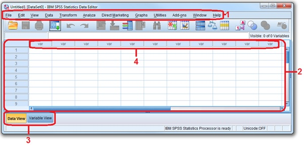

SPSS main window view

- SPSS has two main windows: the data editor, as we’ve just seen in the image above, and the “output window”, which displays the SPSS syntax or code that the buttons you click create to tell SPSS what to do (which you can ignore and you’ll probably find annoying that it’s displayed every time you do something) along with the results of those commands (usually printing tables of results from analyses and producing graphs, which are useful). This only appears once you tell SPSS to do something though. **For simplicity we will just refer to the data editor window as the main window from now on.**

### 5.3.2 Loading data in SPSS

- Next let’s load some data so we can explore the main window (and the output window will appear for the first time). Go back to the main window in SPSS and in the main menu click File > Open > Data. Then in the Open Data tool window that opens navigate to the folder where you unzipped the YCHI5045M computer practical files and go into the “Datasets” folder in the same way you would locate a folder in Windows Explorer. Find the file called “Example basic data.sav” and either double click on it or click on it once and then click the OK button.
- This is an SPSS format dataset (.sav) and therefore contains more data and formatting of the data than other formats such an Excel (.xlsx) or .csv etc. This allows it to store things like variable labels and value codes (see below).
- You will eventually see the output window appear and display some code that is telling SPSS to load the dataset, and then SPSS should take you back to the main window where you will see the raw values of the data in the Data View tab. See number 3 in the image above. The variable names are in the top row and the raw data values are in the cells. You will see there are three variables.

### 5.3.3 The main features of the main window

Refer to the “SPSS main window view” image above and the numbered features:

1. The main menu. This is where you select commands to do most things you need to do.
2. The raw data view. Similar to Excel, here you will see the raw data displayed (although you can choose whether to display categorical variables’ labels or raw values if numerically coded - see below).
3. These tabs allow you to either view the Data View, where the raw data is displayed in the main area (2), or the Variable View, where information about each variable is displayed and where you can edit variables’ characteristics.
4. Variable names will be displayed here once any data are loaded.

### 5.3.4 Variable names/labels

Before going further we will just set an option (or check that it’s already set) in SPSS so that it displays variables’ *names* rather than variables’ *labels* in the various tools we will be using. We will see what the difference between these two things are later. This is because in the instructions below we refer to variables’ names rather than their labels. However, you can certainly choose to display either for your own analyses.

- From the main menu bar go: Edit > Options and then under the General look under the Variable Lists section and select the Display names option as shown below:

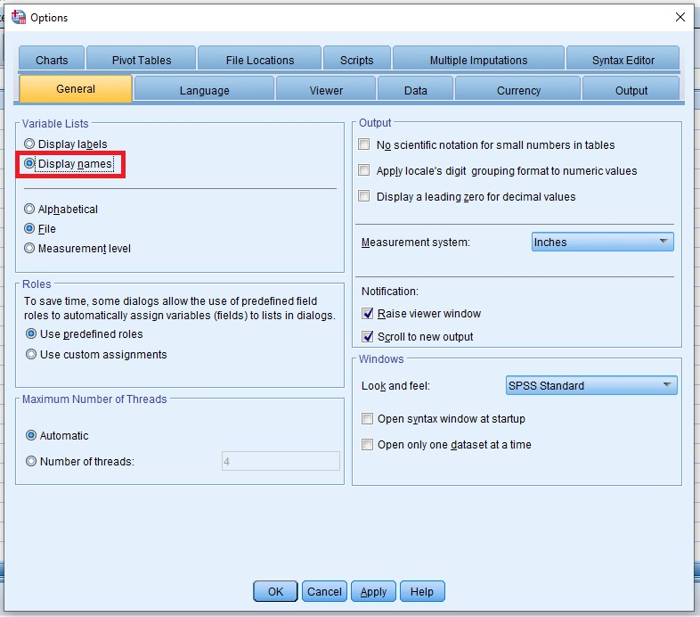

SPSS main options variable identification options

### 5.3.5 The *Variable View* and variable properties

Now that we’ve loaded some example data into SPSS let’s look at the variable properties we can edit in the Variable View tab in the main window.

- **Name** = the variable’s name. Like a file name, this should be short and descriptive and clear.
- **Type** = the “type” of format in which the variable is stored, e.g. numbers, string (letters and possibly numbers and/or characters) etc. Note this is just how the variable is stored, and not the type of variable in terms of categorical, numerical etc (see “Measure” below). You can often just ignore this and you should not alter this unless you know what you are doing!
- **Width** = for string variables, width refers to how many characters a value can hold. Again you can just ignore this and should not alter this unless you know what you are doing!
- **Decimals** = how many decimal places will be displayed (note: changing this does not alter how many decimal places a value actually has stored though).
- **Label** = the descriptive label of the variable, used to briefly describe what the variable measures in more detail than the variable name.
- **Values** = used to create or edit value labels, i.e. labels attached to different numerical values. We’ll come back to this shortly.
- **Missing** = used to set or change which specific values (if any) represent different types of missing data. We will not be using this.
- **Columns** = how wide the displayed columns are currently.
- **Align** = whether values are left or right aligned.
- **Measure** = what type of data are stored in each variable. In the terminology we’ve been using: nominal = a binary variable or a categorical variable with 3 or more category levels, ordinal = an ordinal categorical variable, and scale = a discrete or continuous numerical variable.
- **Role** = I’m not actually sure what this does so presumably it’s not anything that important and you can ignore it. Google if interested!

# 6 Preparing a dataset for analysis

The first step before doing any analysis is to understand and prepare the dataset. If you are lucky this will have been done already, but either way you should still go through this process to ensure the data really are ready for analysis. You may see this stage referred to as data preparation, data cleaning or data cleansing. These can mean different things in different contexts, but in the context of preparing a dataset for analysis we want to ensure the following:

- All variables are correctly named, labelled and set to the correct data type.
- All categorical variables are correctly coded and free from obvious errors.
- All numerical variables are in the correct format and free from obvious errors.

In addition there are often other key features of a dataset that must be checked prior to analysis, but these will be dataset specific and we don’t have time to go into the detail here. However, one common example would be checking that any unique IDs have no duplicated values, and another would be cross checking any variables that are related to confirm they are both consistent, e.g. compare ages with dates of birth (they should agree) etc. To save time we will just do these steps for some of the variables in the *SBP Excel data* dataset to see how they are done, but then use a fully cleaned and prepared dataset for the analyses.

First we’ll load a typical basic Excel dataset that lacks the extra formatting features of an SPSS format dataset, and that also contains typical errors present in raw datasets such as wrongly coded categorical variable observations and clear errors in some numerical variables, so we can see how to deal with these common issues when preparing datasets.

## 6.1 Exercise: loading Excel data

SPSS can load all the main types of data you are likely to need to load, including CSV files, Excel spreadsheets, and data files from various other statistical programs like Stata and SAS. During these practical sessions we will use datasets saved in SPSS’s own format (.sav), which preserves all the useful information on things like variable names and labels, categorical variable coding labels etc that we will see explained below. However, if you use SPSS in the future it is likely you will have to load data in an Excel format at some point. Therefore, the first thing we’ll learn to do is to load an Excel spreadsheet.

[Video: load Excel data into SPSS](https://youtu.be/h9tso_376VA)

Go back to the main window in SPSS and in the main menu click File > Open > Data. Then in the Open Data tool window that opens navigate to the folder where you unzipped the YCHI5045M computer practical files and go into the “Datasets” folder in the same way you would locate a folder in Windows Explorer. Then to allow you to see Excel files look for the Files of type drop-down menu beneath the area in the Open Data tool where the folders and files are displayed, and select the All Files option here. Then click on the “SBP data.xlsx” dataset and then click Open (or double click on the file). A tool window will pop-up called Opening Excel Data Source. Ensure the Read variable names from the first row of data box is ticked and the Worksheet drop down menu is on “SBP data [A1:I557]” and then click OK. You will now see the raw data displayed in the Data View with the variable names in the top row and the data values in the cells. You will see there are nine variables.

## 6.2 Exercise: set variable properties and code categorical variables for errors

Now let’s see how to set key variable properties and how to ensure all categorical variables are correctly coded and free from clear errors.

Video: set variable properties and code categorical variables for errors

First we’ll make sure our variables are correctly named, labelled and set to the correct data type, and that all categorical variables are correctly coded. Note: for some of these exercises we will just edit a few of the variables for practice, but leave the rest alone. This is okay because when we move on we will be using a fully updated version of the dataset so we don’t need to update more than enough to understand the processes. To make these updates we need to know what variables are in our dataset and what data they contain, its units/coding etc. This information would either be available to you if you were the one who collected the data, or it would be made available in a “codebook” if you were using secondary data (hopefully). A codebook just describes all variables in a dataset in full detail. We’ll use the following table of key variable details for the *SBP Excel data* dataset when updating our variable details in SPSS:

*SBP data* dataset variable details

| Variable name | Variable type | Variable description (units/coding of levels) |
| --- | --- | --- |
| sbp | Numerical: continuous | Systolic blood pressure (mmHg) |
| htn | Categorical: nominal (binary) | Hypertension (SBP >= 140 mmHg, 0 = no/1 = yes) |
| age | Numerical: discrete | Age (years) |
| sex | Categorical: nominal (binary) | Sex (1 = male/2 = female) |
| ses | Categorical: nominal | Socio-economic status (1 = low/2 = medium/3 = high) |
| salt | Numerical: discrete | Salt consumption (g/day) |
| bmi | Numerical: continuous | BMI (kg/m2) |
| ace | Categorical: nominal (binary) | ACE inhibitor usage for at least 3 months (1 = yes/2 = no) |

### 6.2.1 Variable names

- On the Variable View tab look at the Name column. Here you see the variables’ names. Variable names are short terms used to refer to the variables, a bit like file names. Variable names should be short, clear, understandable and unambiguous. We’ll leave these as they are, but just so you can see how to edit them click on the variable name “id”, delete it and re-enter it.

### 6.2.2 Variable labels

- Next in the Variable View look along to the Label column where the variable labels can be stored (there are none in this dataset yet as Excel cannot store such information). Variable labels allow you to briefly describe the variable in more detail than the variable name. Good practice is to include the units for numerical variables or the coding scheme for categorical variables. Let’s add some for practice:
- For the variable sbp click on the variable label cell and enter “Systolic blood pressure (mmHg)”, i.e. the brief description of the variable with the units included take from the codebook table.
- Now click on the variable label for ses and enter the description provided in the codebook table (you can just copy and paste it from the table).
- Feel free to update the variable labels for some other variables if you wish, but once you’ve know how to do it you can move on.

### 6.2.3 Variable types

- It is very important that variable types are correctly set in SPSS (and all stats packages), because it affects the way analyses and other things like graphs may work, with incorrectly defined variable types resulting in errors. To set the variable type go to the Variable View and click on the relevant cell under Measure (it will either say “Scale” or “Nominal”) and select the correct type from the drop-down menu. SPSS will set the Measure based on the nature of the variable: for any variables with any non-numeric (i.e. letters or special characters) values the variable Type will be String and the variable Measure will be Nominal, and for any variables with only numeric (discrete or continuous) values the variable Type will be Numeric and the variable Measure will be Scale. However, these automatic choices may not be correct for the dataset!
- For our dataset let’s start with sbp. What do you notice about its Type and Measure? The Type is String and the Measure is Nominal. What about if you click on the Measure cell? Only nominal and ordinal options are available! This means that at least one value in the variable is non-numeric, i.e. a letter or special character. Unfortunately there are no easy ways to check which values are non-numeric (there are ways using more complicated functions, but we don’t have time for that here), but if you create a frequency table (see later for how to do this) and scroll through all the values you may be able to spot the problem values. However, to save time here the issue is observation number 93, which has a value of 1o3, i.e. with a letter “o” instead of a zero.
- To update the erroneous value go to the Data View and either scroll down to the value (observation 93) and update it, or click on the sbp column variable name/heading to select the whole variable, then press **ctrl** and **f** to open the Find and Replace - Data View tool (below the Find tab it should say “Column: sbp”), then click on the Replace tab and then in the Find text box enter “1o3” (without the quotes) and then in the Replace text box enter “103” (without the quotes) and press the Replace button at the bottom to correct the value.
- Once the error has been updated go back to the Variable View window and update the variable Type for sbp to Numeric, because only Numeric type variables can be Scale variables (sorry for the confusing terminology, I don’t like SPSS’s choices!). Click on the relevant cell for sbp under Type and click the little box with three dots that appears to the right. Then select Numeric and then OK. As there are no more values with strings or non-numeric characters in you should now be able to update the variable’s Measure to Scale!
- You can go through all other variables and ensure the variable **Type** and **Measure** characteristics are set correctly if you wish, but once you’re happy how this is done feel free to move on.

### 6.2.4 Value labels: coding categorical variables

- Categorical variables must use some type of coding or coding scheme to be understandable. This just refers to how categorical variables’ levels are stored (e.g. our sex variable has two levels: male and female). There are two approaches:
1. String/character coding: each categorical level is referred to via a string (i.e. a set of letters, numbers or special characters). E.g. sex might take either the value “male” or “female”.
2. Value coding: each categorical level is referred to via a number, with the number linked to a “value label” that then describes what that level represents. E.g. sex might take either the value 1 or 2, where 1 is linked to the value label “male” and 2 is linked to the value label “female”.
- You can use either approach in SPSS and you shouldn’t have any problems. However, as value coding is often used and requires more understanding of SPSS to add/edit we will follow this approach so you can get the practice.
- So let’s set-up value labels for our categorical variables sex and ses. To do this we must ensure that they are correctly coded with numbers and that suitable value labels are attached those numbers. In “real life” we would repeat this process for all other categorical variables. Before making any changes though we must first check each categorical variable to find out what levels exist and if there are any errors – you might be surprised. The easiest way to do this is to generate a frequency table: a table listing the number of cases the percentage of cases with each level.
- From the main menu go: Analyze > Descriptive Statistics > Frequencies. Note that SPSS tries to work out the type of variable based on the values present, e.g. if there are any non-numerical characters it will assume a categorical variable. In SPSS categorical variables are represented by three coloured circles, and numerical variables by a small ruler symbol. However, these assumptions will not necessarily be correct. Let’s look at sex and ses. Either double click on the sex and ses variables in turn or click once on each while holding the **shift** button and then click the right pointing arrow to add them. Then ensure the Display frequency tables button is ticked and click OK. The results will appear in a new output window, which is the other main window in SPSS where all results will be displayed along with any error messages.
- Now look at the frequency table to see what levels are present for sex and ses and how they are coded. Note that sex has been entered as a string variable (with levels recorded as words) and ses has been entered as a numeric variable (with levels recorded as numbers). Now you can see why frequency tables are so useful for data cleaning. For sex you can see that there are five levels, and it’s clear that three are errors (both the fact there are clear spelling mistakes/odd values and the fact they only occur once indicate they are mistakes). Specifically the levels “*1*”, “*FM*” and “*mal*” need correcting.
- We therefore need to first clean/correct the error values, and then convert all values to numerical values and then add the labels. Look at the codebook above and the “Description (units/level coding)” column for the correct coding to apply to each level. To correct the mistakes go back to the Data View and click the top of the sex column (click on the word sex) to highlight the whole column. Then hold **ctrl** and **f** to open the Find and Replace - Data View tool. Then in the Find text box enter “1” (without quotes) and in the Replace with text box enter “male” (without quotes) and then click Replace All. Repeat this find and replace process for all other levels that are errors with the obvious correct word. Then use the find and replace process to change all “male” values to the number 1, and all “female” values to the number 2. We can now add value labels to these numerical codes. Be sure to add labels to the correct numerical values or they won’t display.
- Now go back to the main window Variable View and click on the Values cell for sex where it currently says “None”. You’ll see a small box appear to the right of the cell with three dots in it – click on this to open the Value Labels tool. Then click the Value text entry box and type 1. Then click the Label text entry box and type “male”. Then click Add. Then repeat for Value = 2 and Label = “Female” (make sure you remember to click Add). Then once both value labels are added click OK.
- Next let’s correct (if necessary) and code ses. Go back and look at the frequency table for ses. We can see there are four levels with one obviously incorrectly coded level of “11” only observed once. Clearly this should be coded as “1”. Use the find and replace process detailed above to replace level “11” with “1”, and then attach the correct value labels to the levels 1, 2 and 3 based on the information provided in the codebook table (1 = low, 2 = medium and 3 = high).
- Note: variable labels and value labels are not stored in Excel files, so to retain them you must first save your dataset in SPSS “.sav” format. This can be done by going from the main menu to: File > Save As, and then selecting a folder and file name. The .sav format should be the default selected, but ensure that you save your updated dataset in this format.

## 6.3 Exercise: check numerical variables for clear errors/anomalous values and correct as necessary

Video: check numerical variables for errors/anomalous values

## 6.4 A final note on data cleaning

We will end our data cleaning there having seen how to clean and prepare all variables as best as we can in isolation. However, with a real dataset these steps would just be the basics, and we would want to look further to check for errors and anomalous values by also looking at relationships between variables. For example, if we looked at a scatter plot of sbp ~ age we may see a suspiciously high value for sbp for a very young participant, i.e. one that would be very unlikely in such a young individual. We could then check this with any prior data or the participant if we were able to.

**Note: it’s considered a good rule that you should only delete an observation from a given variable if you can confirm beyond reasonable doubt that it is an error, and that any data deletions must be reported in any results section of a paper/report etc. If you are concerned that one or more observations for one or more variables are errors but you cannot confirm this then a good approach is to run your analyses with and without those data points, and then in your results explain if this made any difference to your conclusions and discuss the implications accordingly.**

# 7 Describing a dataset

## 7.1 Background

If you are still unclear on the difference between descriptive statistics and inferential statistics, or want a brief refresher, you can read the below information.

## 7.2 Descriptive statistics and inferential statistics

It’s important to be very clear on the distinction between descriptive and inferential statistics. Descriptive statistics simply describe the characteristics of variables or the relationships between variables in your sample, i.e. the dataset you have collected, and they do so *without any uncertainty*. They consist of “point estimates”, or statistics that take single values, such as means and percentages. However, they do not allow you to make robust generalisations about the characteristics of variables or the relationships between variables in the target population (or more widely if plausible) from which the sample was taken. To do that requires inferential statistics such as (most commonly) confidence intervals and p-values. Note though that inferential statistics are usually presented and interpreted along with relevant descriptive statistics to allow inferences to be made. For example, confidence intervals are usually presented *around a relevant point estimate or descriptive statistic*, where the point estimate is taken as the single best estimate of the likely value of the population parameter and the confidence intervals provide a range of values that are consistent with the likely value of the population parameter.

This terminology can be a source of confusion particularly for survey-type studies, where we often say we are aiming to *describe* the characteristics of a given target population, but what we mean is we are going to use inferential statistics (typically confidence intervals around our point estimates) to say something about the likely characteristics of our target population (i.e. to describe their likely characteristics). However, we are not implying that we are going to use descriptive statistics alone to do this, as descriptive statistics (i.e. point estimates such as means and percentages) on their own don’t allow us to say anything robust about the likely characteristics of our target population.

To illustrate the difference: if we have a list of all post-graduate students of the University of Leeds and we take a simple random sample of 100 of those students and measure their blood pressures (mmHg) we can calculate the mean blood pressure for the sample exactly (i.e. the mean blood pressure of the sample would be a descriptive statistic describing the typical value of blood pressures in the sample). Similarly, if we were able to measure all of the students’ blood pressures we could then also calculate the exact mean blood pressure for the target population, i.e. all UoL post-graduate students, which would also be a descriptive statistic describing the target population. But in practice such a census is not possible. Therefore, if we want to say something about the likely mean blood pressure in the target population, i.e. all post-graduate students at the UoL, based on our sample alone we need to use inferential statistics. For inferring characteristics about single variables we typically calculate the relevant sample statistic from the sample, which is just identical the descriptive statistic, and is the best single or “point estimate” of the likely parameter of interest (e.g. the mean) in the target population (assuming a random sample, or more technically a probability sample). For our example this would be the mean blood pressure (mmHg). Then to allow us to make inferences/generalisations to our target population, that we took our sample from, we could estimate confidence intervals (usually 95% CIs) around that sample statistic. In other situations, for inferring relationships between variables we might estimate the difference between two variables or the correlation or a regression coefficient, which again are all sample statistics and on their own can be used as descriptive statistics, but for inference we would then also compute the relevant confidence intervals, and maybe also compute p-values where there are useful null hypotheses that we can test about those statistics.

## 7.3 Exercise: create descriptive statistics

### 7.3.1 Overview

In the YCHI5045M computer sessions materials “Exercises” folder open the “Exercises.docx” Word document and scroll down to **Descriptive statistics table** The aim of this exercise is to complete the empty table by calculating the values of the relevant descriptive statistics for the variables in the table (i.e. the key variables in the dataset). Note: the footnotes to the table are typical of such tables in papers and allow us to just present a single column of descriptive statistics. However, you could of course present the values in other ways. Once you’ve completed your table you can compare it to the completed one at the end of this section to see how you did.

See below for instructions about how to do this in SPSS.

Video: calculate descriptive statistics

- First load the “SBP data final.sav” dataset, which has all the errors removed from the “SBP Excel data.xlsx” dataset, and all the variable properties like variable labels and value labels etc updated.

### 7.3.2 Categorical variables

- To calculate descriptive statistics for the categorical variables we just need to produce frequency tables for each variable and extract (i.e. copy) the counts for each category level and the corresponding percentages. Simple! From the main menu go to: Analyze > Descriptive Statistics > Frequencies. Then in the Frequencies tool window add all categorical variables to the Variable(s): box. You can either drag each variable across one-by-one by clicking and holding down the left mouse button, or you can click on each one and then click the button in between the two boxes to move it over (or to move it back), or you can select multiple variables and move them at the same time in the same way by first holding down **ctrl** and then clicking on as many variables as you want to before moving them. Note: this is the typical behaviour of these types of variable boxes in SPSS and you will spend quite a lot of time moving variables so it’s good to try the different methods. Once you have moved all the categorical variables in the table over to the Variable(s): box just ensure the Display frequency tables box at the bottom of the tool is ticked and then click OK. After a moment in the output window you should see the tables appear (one for each variable). You can now copy the relevant values from the **Frequency** and **Percent** columns into the table.

### 7.3.3 Numerical variables

Once you’ve completed your table compare your results to the completed Table 1 for this dataset below:

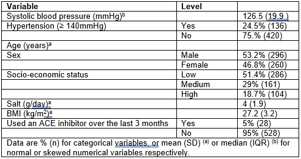

Completed Table 1 for SBP dataset

If you have any glaring errors or strange differences try and work out why, and if you can’t then ask for help!

# 8 The independent t-test

## 8.1 Overview

The independent t-test allows you to compare whether two independent groups differ in their mean values of some numerical outcome, or less formally whether individuals in one group have higher/lower values for some numerical outcome than individuals in another group, on average. Therefore, it is suitable when your outcome is numerical and your single independent variable is binary. For example, if you wanted to analyse whether a group of women had a different mean systolic blood pressure from a group of men. Therefore, the independent t-test is suitable for when your outcome is numerical and your independent variable is binary. Strictly speaking the outcome should be continuous and normally distributed for each group, but the independent t-test is very robust to non-normally distributed outcomes and as long as the outcome isn’t strongly skewed for each group it should be okay to use this test. Note: with the independent t-test the independent variable is binary and might naturally consist of a categorical variable with just two levels (like sex), or we might construct a binary variable from a categorical variable with >2 levels (e.g. reclassifying socio-economic status from low, medium and high levels to just low/medium and high levels by pooling individuals in the low and medium levels), or we might create a binary variable from a numerical variable based on a threshold cut-off (e.g. BMI ≤20 vs BMI >20). We’ll look at the last of these scenarios as it requires a bit more preparation, so you will know how to do this if needed in SPSS.

## 8.2 Scenario

Using the SBP dataset we’ll see how we can use the independent t-test to compare whether the mean systolic blood pressure (mmHg) differs between individuals aged ≤40 compared to those aged >40, and then you can try a similar analysis by yourself.

## 8.3 Step 1: check the assumptions of the independent t-test are not violated

Video: check the assumptions of the independent t-test are not violated

Whenever you run a statistical analysis you must ensure that the assumptions of the analysis are not violated, otherwise the results may not be valid or even meaningful. For simple analyses like the independent t-test we can check the assumptions before we run the test, but for more sophisticated analyses such as regression models we typically check the assumptions after running the analysis because SPSS produces the information to make the necessary checks only after running the analysis.

The independent t-test makes the following assumptions:

**1. Continuous outcome**

Technically an independent t-test assumes a continuous outcome variable, but as long as assumptions 2 and 3 below are satisfied it’s fine to use a discrete outcome with an independent t-test. Here our outcome is continuous. Note: ideally when analysing a discrete outcome you would use a more specific model like a Poisson or negative binomial model, but this is beyond the scope of this introductory course.

**2. Independent groups (hence the “independent t-test”)**

This means the observations in each group cannot be related. You can only really verify this by knowledge of your study design. With the SBP data the study took a **simple random sample** of individuals and we are then dividing them into two groups based on an age threshold. Therefore, by definition the two groups are statistically independent as all observations represent separate, randomly sampled individuals.

Typically groups are only not independent in two situations. First, if you were taking repeated measurements from the same set of individuals but treating the measurements at each time period as different “groups”. Here there would be correlations between the measurements at the different time periods within individuals. Second, if you were taking measurements from two groups of separate individuals, but the individuals in the two groups were not statistically independent. For example, if there were different families with members in both the age groups, or if there were individuals from the same work places within each group. Again, in such situations there would be correlations between members of the same family or work place (e.g. due to genetics or shared risk factors etc).

Here our groups or observations are clearly independent as the individuals in the study were randomly sampled and the two groups contain separate individuals.

**3. The outcome is approximately normally distributed within each group**

Note: technically it is the “residuals” or “model errors” that need to be normally distributed, which are the differences between the observed values of the data and the “model predicted values”. For a t-test these are simply the differences between the observed values of the data and the mean of the relevant group that the observation comes from, which actually means that for a t-test the residuals are identical to the observed values and so you can just view the distribution of the observed data. For more complicated regression models we’ll see that we need to calculate and plot the residuals separately.

To check the distribution of the residuals within each group you can use statistical tests, but most statisticians would recommend using graphical methods. We can visually check these two distributions easily in SPSS using histograms as follows. From the main menu go: Graphs > Legacy Dialogues > Histogram. Then add the sbp variable into the Variable: box, then add the age_young_old variable into the Rows: box, tick the Display normal curve box and then click OK. You’ll see a histogram for the sbp variable for each age group. As you can see the outcome approximates a normal distribution fairly well for the ≤40 age (this is probably as good as you would see with real data), and is slightly right skewed for the >40 age group. However, as previously mentioned the t-test is pretty robust to slightly skewed outcomes so this is nothing to worry about, and we can assume this assumption is met. Below are some examples of suitably and unsuitably distributed data for you to compare with for future reference.

Students (and researchers) often struggle with knowing whether an analysis’s assumptions have been violated or not, and for good reason because it usually involves judgement based on experience. For the t-test like most analyses requiring normality there is no agreed “threshold” for when the skewness of a variable is considered “non-normal”. However, as t-tests and regression models are fairly robust to some non-normality the following examples should hopefully give you a sense of when you are okay to go ahead and when you are violating the assumptions and need to transform the data or use a different model.

**A. Probably suitably *approximately* normally distributed data within each group for a t-test, with n = 50 per group:**

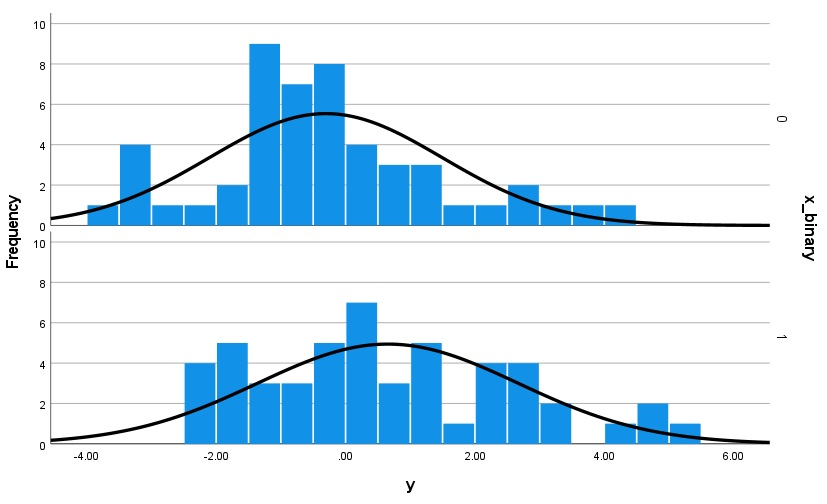

With only 50 data points per group the distribution is pretty “lumpy” but you can see an approximate normal distribution in both groups, although less so for the lower group. Also note: these data are generated from a normal distribution, so you can see that when your sample size is low even with artificially simulated data from a known normal distribution the resulting sample can often be only somewhat approximately normal! You can also see that the variance in both groups looks approximately normal, which satisfies our next assumption (see below).

**B. Highly suitably normally distributed data within each group for a t-test, with n = 500 per group:**

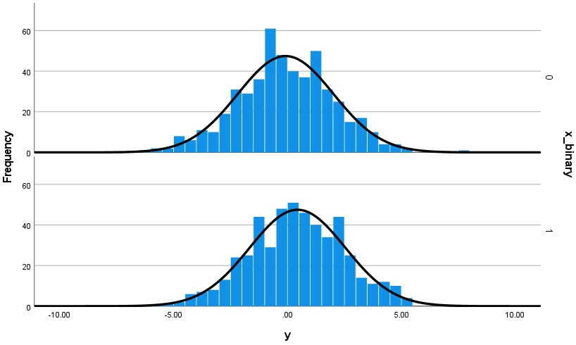

Now with 500 data points per group simulated from the same distribution unsurprisingly the distribution looks much more suitably normal.

**C. Probably not suitably normally distributed data within each group for a t-test, with n = 50 per group:**

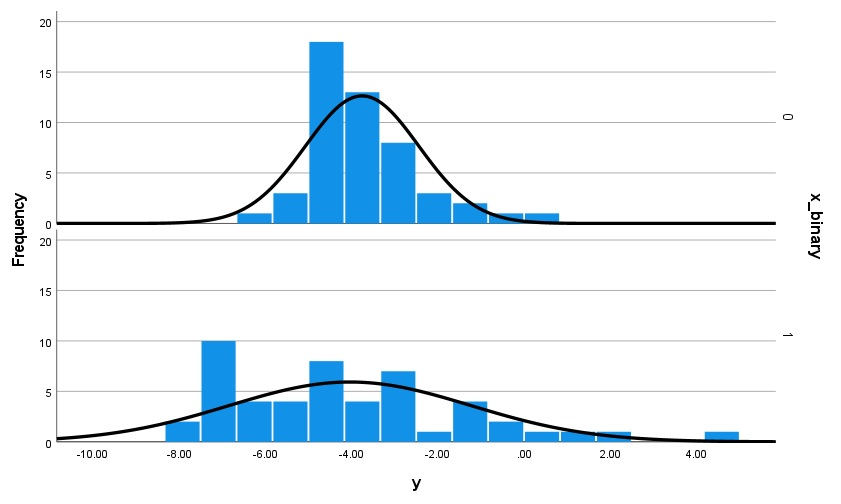

You may think it doesn’t look much different from the first image, and you’d be right. Again, it comes down to judgement but when sample sizes are small there’s a lot of subjectivity involved. These data are simulated from a right-skewed “version” of the normal distribution. If you are concerned one option is to run your test on the raw data and then transform the data (we’ll see later how to do this) and re-run the test and see if the results change much, and just report both. This is called a sensitivity analysis.

You can also see that there is a lot more variance in the lower group’s data, which would violate our next assumption (see below).

**D. Definitely not suitably normally distributed data within each group for a t-test, with n = 500 per group:**

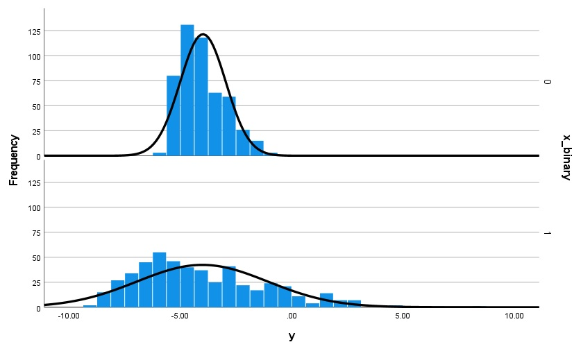

Now with 500 observations per group it’s clear that there is some definite right-skew in the distribution of both group’s data, and that there is considerably more variance in the lower group.

**4. Equal variances in each group**

This means that the variance (dispersion or spread) of outcome values is approximately the same in each group. We can check this by looking at the p-value for a test of this assumption called “Levene’s test of equality of variances” or by comparing the histograms from the two groups. SPSS produces the results of the Levene’s test when we run the t-test, so we will evaluate the results of this test/assumption once we’ve produced our t-test results below. Note: if this test is significant (P<0.05) we can simply use the results from the version of the t-test that doesn’t assume equal variances in each group. The only disadvantage is that we lose a little bit of statistical power, but typically it’s not much and the results will be very similar. Hence, although we’ll interpret the “equal variances assumed” version of the t-test below it’s probably a better practice to just always use the more conservative but robust and safer set of results that do not assume equal variances is each group.

## 8.4 Step 2: create an binary independent variable from a numerical variable

Video: create an independent variable from a numerical variable for the independent t-test

Next we need to create a two-level categorical variable defining our younger and older individuals. Usually you should choose the cut-point at which you define your two-levels based on theory or some sensible motivation (e.g. the age at which prior research suggests blood pressure may often change), but here let’s just compare those individuals above and below the *median age*, which is 40. We therefore want to create a variable that classifies every individual as either ≤40 or >40.

- First, we can use the Compute Variable tool to create a new variable based on a logical test of whether the value in the original age variable is ≤40 or not. This will create a new variable that has the value 0 if the participant’s age is >40 and the value 1 if their age is ≤40 (i.e. if the logical check we asked SPSS to do on the original age variable is TRUE then the new variable’s value is 1). From the main menu go: Transform > Compute Variable. Then in the Compute Variable tool enter “age_young_old” as the name for the new variable in the Target Variable: box. Then in the Numeric Expression: box enter:

> age <= 40

Then click OK.

- The output window will appear. Minimise this to go back to the main window and go to the Variable View. You should now see our new variable age_young_old has appeared. Let’s give it a variable label so it’s well described in SPSS: Age (0 = >40 / 1 = <=40). Then let’s give it some value labels so each level is well described. As it was created from a logical expression it takes only two values: 0 or 1. 1 should be coded as “≤40”, because when the participant’s age was less than or equal to 40 the logical expression would be true and the new variable would take the value 1. Similarly 0 should be coded as “>40” as the logical expression would be false and the value set to 0. Check back to the instructions on adding value labels or ask if you need help.
- Lastly, once that’s done you should always do a quick check that the variable has been created correctly using a “cross tabulation” between our old and new age variable. In the main menu go: Analyse > Descriptive Statistics > Crosstabs. Then in the Crosstabs tool add the original age variable into the Row(s): box and the new categorical binary age variable into the Column(s): box and click OK. If you’ve created the new age variable correctly all ages ≤40 should be counted in the age <=40 column and all ages >40 in the new age variable age >40 column. Always perform such checks when creating new variables!

## 8.5 Step 3: run the independent t-test

Video: run the independent t-test

- In the main menu go: Analyse > Compare Means > Independent Samples T Test. Then in the Independent-Samples T Test tool add the sbp variable into the Test Variable(s): box. Then add our new independent variable for age group (at the bottom of the list) into the Grouping Variable: box and click Define Groups…. This is where we tell SPSS what numerical values code for each of our two groups, and what way round we want to compare the two groups. Remember we created the age variable so that it took the value “0” for individuals >40 and “1” for individuals ≤40. Let’s compare individuals >40 to individuals ≤40. When it comes to comparing the groups this tells SPSS subtract the mean outcome in group 0 from group 1, i.e. the mean systolic blood pressure for individuals >40 minus the mean systolic blood pressure for individuals ≤40. To do this ensure the Use specified values option is selected and add the value “0” to Group 1: and the value “1” to Group 2:.
- Note: you can of course swap the coding values around and compare individuals ≤40 to individuals >40 and your results will be reversed but otherwise identical. Neither choice is necessarily “correct” it just depends on which way round you want the groups compared. If, in your version of SPSS, there is a box called Estimate effect sizes below the Grouping variable: options make sure this is not ticked. Finally click Continue and then OK. You’ll now see the output window appear with our results!

## 8.6 Step 4: understand the results tables and extract the key results

Video: understand the results tables and extract the key results

Now we’ve verified the first two assumptions of the independent t-test (independent observations and approximately normally distributed residuals) let’s look at the results tables where we can check the third assumption (equal variances in each group), extract the key results and interpret them.

So what do the tables mean?

**Group Statistics table explained**

The first table we see gives us descriptive statistics for the outcome variable for each level of our categorical independent variable.

- First, make sure you look at and record the values under the “N” column, which are the group sample sizes, and check they match what they should be. You should see there were 295 individuals in the ≤40 group and 248 individuals in the >40 age group. These sum to 543, which is less than the total number of individuals in the dataset: 556. There are three reasons why this might be: either some individuals are missing values for the outcome or the independent variable or both variables. We know from when we prepared the dataset that some individuals are indeed missing values for their systolic blood pressure. You can quickly check this by going to the Data view, right clicking on the sbp variable and selecting Descriptive Statistics. In the **Statistics** results table that appears you should see that there are indeed 13 individuals with missing values for sbp, and hence only 543 individuals with complete data on this variable, which explains the sample size of the independent t-test.
- Next make sure you look at and record the mean value of the outcome for each group under the “Mean” column. You should see the mean systolic blood pressure (mmHg) was 128.2 for individuals >40 and 125.1 for individuals ≤40 (rounded to 1 decimal place).

**Independent Samples Test**

This table gives us the results of the t-test we’re interested in, although SPSS lays out the results less than clearly in my opinion. Here’s what they all mean.

**Levene’s Test for Equality of Variances section columns explained**

Under this part of the table are results that relate to a statistical test that is totally separate to the independent t-test called “Levene’s test for equality of variances”. This tests whether the variance (spread) of the outcome in each group is approximately equal. If they are not then this assumption is violated and we must only use the results from the version of the independent t-test that accounts for this.

**F**

- The F-value is the test statistic for the Levene’s test for equality of variances. You can ignore it as it is used to calculate the corresponding p-value of the test (see below), which is all we are interested in.

**Sig.**

- The “Sig.” value is just the p-value associated with the test statistic (i.e. the F-value). For some reason SPSS always refers to p-values with a “Sig.” column heading. The null hypothesis for the Levene’s test is that the variances in both groups are equal. Therefore, if the p-value (“Sig.”) is <0.05 this indicates that the variances in the two groups are *unlikely to be equal*. If this is the case it is then safer to use the version of the *independent t-test* that does not assume equal variances. Results from both versions of the independent t-test are presented. Just look at the far left of the table and you can see the top row of results are for the “Equal variances assumed” version and the bottom row for the “Equal variances not assumed” version.
- Here you should see that the p-value for the test is **0.244**, i.e. it’s >0.05. Therefore, we can assume the variances are approximately equal in each group. Hence, we can use the results for the independent t-test from the row called **Equal variances assumed** (see below).
- **Note: SPSS only gives p-values to 3 decimal places, so when it says “0.001” it means the p-value is actually <0.001. Therefore, you should write P<0.001.**

**t-test for Equality of Means section columns explained**

**t**

- This is the value of the t-test statistic which is used when calculating the p-value. We can ignore this and just interpret the p-value directly (and of more use the confidence intervals).

**df**

- This is the degrees of freedom which form part of the calculation of the test statistic (calculated as: n - 2). You can typically ignore this but it should closely match your “true” sample size, i.e. the number of genuinely independent observations.

**Sig. (2-tailed)**

- This is the two-tailed p-value for the independent t-test. The “two-tailed” part means that it allows for the possibility that the difference between the two groups may be positive or negative, i.e. either group might have a greater mean than the other. The null hypothesis of the independent t-test is that the “true” difference between the two groups in the target population from which the sample was taken is exactly 0. Therefore, this p-value tells us how likely we are to have observed data giving a mean difference at least as great or greater (in either direction) as the one observed. Alternatively, you can more loosely interpret it as a probability measure of how consistent the data are with the null hypothesis of no difference. Again note that SPSS only gives p-values to 3 decimal places, so when it says 0.001 it means the p-value is <0.001.
- Here you should see that the p-value is **0.072**.

**Mean Difference**

- This is the difference between the mean of the outcome for the group that we set as “Group 1” minus the mean of the outcome for “Group 2”. For us this means the mean SBP of participants aged >40 minus the mean SBP of those aged ≤40. It therefore tells us the direction and size of any difference, and is therefore a key result/statistic from the test. You can swap the coding of the groups around if it makes more sense (just go back and re-run the analysis but change the coding), but the difference will be reversed (i.e. a positive difference will become a negative difference).
- Here you should see that the mean difference (rounded to one decimal place) is **3.1**.

**Std. Error Difference**

- This is the standard error of the mean difference, which estimates the sampling variability associated with our estimate of the parameter in the target population. This is used when calculating the 95% confidence intervals and the p-value. You can ignore it and just interpret the confidence intervals and p-value.

## 8.7 Step 5: report and interpret the results

Video: report and interpret the results

**Reporting the results**

> Methods: explain that you used an independent t-test to analyse the data and justify why.

> Discussion: interpret the direction and size of the difference in terms of the implications for practice and policy. Is the difference “statistically significant”, i.e. can we make a clear inference that there even is a difference on average between the groups, and if so is it a small difference, a medium difference, a large difference etc in terms of what is being measured and the implications for practice and policy?

**Interpreting the results**

How do we actually interpret these results then? Remember with statistical inference we are aiming to make a “probabilistic inference”, or a generalisation with some level of uncertainty, about the likely value of the population parameter of interest, which here is the mean difference in systolic blood pressure between individuals aged >40 compared to individuals aged ≤40 in our target population, based on the data from our sample. And our confidence intervals around our sample statistic (the sample mean difference) are what allow us to do that. More specifically, the confidence intervals around the mean difference tell us that the mean difference in systolic blood pressure between individuals aged >40 compared to individuals aged ≤40 in the target population is “quite likely” to be somewhere between -0.3 and 6.5 mmHg. Alternatively and equivalently we can interpret the results in terms of an “average individual” in our target population, and say that the confidence intervals tell us that in the target population the systolic blood pressure of individuals aged >40 is “quite likely” to be between 0.3 mmHg *lower* to 6.5 mmHg *higher* than individuals aged ≤40 *on average*.

Note: strictly or technically speaking our confidence intervals tell us how much error is associated with our *sampling process*, and that if we repeated our study many times 95% of the time the 95% confidence intervals that we obtained around our estimated mean difference would contain the true mean difference in the target population. Therefore, our interpretation of the value being “quite likely” to fall within our given confidence interval range is somewhat informal and loose, but probably fine for most research purposes.

Also note: critically this interpretation assumes that all other sources of bias are negligible, which is extremely unlikely! Therefore, you should always treat inferential results very carefully, and evaluate them in the context of how much likely bias there is in the results other than sampling error, which is the only source of bias that inferential statistics account for. E.g. if you knew there was likely a large amount of other sources of error in the study, such as uncontrolled confounding, then the 95% confidence intervals would not accurately reflect the total error or bias in the results because they can only account for sampling error in the absence of all other errors/bias.

Consequently, our confidence intervals indicate that we can’t have much confidence over whether there is even a positive or negative difference in systolic blood pressure between these two groups in the target population, let alone how big any difference is with any great precision. However, the result does tell us that the practical significance or clinical significance of the true difference in mean systolic blood pressure between these two groups is likely to be small, given the confidence intervals suggest it is likely to be at most just 6.5 mmHg (the confidence interval furthest from 0). Always remember though, this is a *probabilistic* result (not certain) and there is always still a non-negligible chance that the true difference is greater, possibly much greater, than we estimated, i.e. outside the range of the 95% confidence intervals, and as above this is actually inevitable with any study unless completely free of other sources of bias.

Lastly, note: when setting up the t-test if we swapped the order of the comparison around we would get the same result but expressed as the ≤40 age group compared to the >40 age group, and so we’d get a mean difference of -3.1 mmHg (95% CI: -6.5, 0.3). Note the 95% confidence interval order is also reversed.

## 8.8 Limitations

The key limitations of the independent t-test is the inability to look at differences between >2 groups or between the outcome and numerical variables, and the inability to control for other covariates. Therefore, with observational data there is a very high risk (essentially a certainty) that the result will be biased due to confounding to a greater or lesser extent, and with experimental data you have no ability to increase the precision of your estimate by controlling for variables that may explain some of the variation in outcomes. As we will see in the linear regression practical once we control for other variables, which likely confound the sbp ~ age relationship, we find there is apparently evidence of a (small) relationship between age and SBP.

## 8.9 Exercise: independent t-test

Using the “SBP final data.sav” dataset and via the process outlined above use an independent t-test to analyse the relationship between BMI and systolic blood pressure.

- Divide bmi into two groups based on BMI values <30 kg/m² and those ≥ 30 kg/m², which are the values typically used to define obesity when defined in terms of BMI.
- Compare individuals with BMI values <30 kg/m² to those with BMI values ≥ 30 kg/m² using the independent t-test.
- Extract the mean difference and confidence intervals around this estimate.
- In the YCHI5045M computer sessions materials “Exercises” folder open the “Exercises.docx” Word document and scroll down to **Independent t-test: the relationship between BMI and systolic blood pressure**.
- Write a couple of sentences reporting the results of your analysis. Include the basic descriptive statistics: sample size, group sizes and group outcome means. Also be sure to include sufficient details about the outcome variable and the comparison made, including how the two independent groups were defined, as well as the type of analysis used, and of course the key inferential results. Round results to one decimal place. You don’t need to explain anything about the study or interpret the clinical or practical importance of the result.
- Write a sentence or two about the key limitations of this analysis *in terms of interpreting the result*.
- Once you’ve completed this compare your reporting to the below example text.

Using an independent t-test I analysed the relationship between BMI and systolic blood pressure (mmHg) for individuals having low compared to high BMI (<30 kg/m² compared to ≥ 30 kg/m²). Out of a total sample size of 516 individuals, 419 individuals had a BMI <30 kg/m² (mean systolic blood pressure = 121.6 mmHg) and 97 individuals had a BMI ≥ 30 kg/m² (mean systolic blood pressure = 146.7 mmHg). This represented a mean difference of -25 mmHg (95% CI: -28.9, -21.2) for those with a BMI <30 kg/m² compared to those with a BMI ≥ 30 kg/m². Therefore, having a BMI < 30 kg/m² appears to be associated with a substantially lower systolic blood pressure on average than having a BMI ≥ 30 kg/m². However, the key limitation of this analysis is that it does not adjust for any other confounding variables, of which there are likely to be many (especially in an observational cross-sectional study like this). Therefore, this is likely to represent a biased estimate of the independent relationship between BMI (as defined/grouped here) and systolic blood pressure in the target population.

## 8.10 Next steps (optional)

If you have time and want to practice and learn more you can try the following exercises:

- Repeat the independent t-test but reverse the coding of the groups to convince yourself that the results are identical but just reversed.
- Use the independent t-test to analyse whether there is a difference in the mean systolic blood pressure between individuals from different socio-economic groups (ses variable). As there are three socioeconomic groups in the variable this would require you to first recode the ses variable into a new variable so that two of the socio-economic groups are pooled to give a binary variable.

# 9 The independent t-test: skewed outcome

## 9.1 Overview

What if, based on your research question, your data are apparently suitable for analysing via an independent t-test, but you found that the outcome was actually heavily skewed? This is particular common with count data (i.e. variables that can only take integer values from 0 onwards) where outcomes are typically right skewed because there are no negative counts, many low value counts and fewer higher value counts. Given that the independent t-test assumes, at least approximately, normally distributed data within each comparison group, let’s look at how we deal with a right-skewed (non-normal) outcome.

## 9.2 Scenario

Using a different dataset than the SBP dataset we’ll see how to deal with a skewed outcome variable that violates the assumptions of the independent t-test while still using the independent t-test to analyse the data. Then you can try a similar analysis yourself.

Load the “Ebola data.sav” dataset. Again this is a simulated dataset. There are three variables and every observation is meant to represent a record from a separate village in a hypothetical region suffering from an Ebola outbreak. The variables contain the following data:

- **n_ebola_cases** = number of Ebola cases per village
- **n_chw** = number of community health workers per village
- **pop_density** = relative population density per village (1 = <10 per 100m², 2 = ≥ 10 per 100m²)

## 9.3 Step 1: check the assumptions of the independent t-test.

Video: check the assumptions of the independent t-test

**1. Continuous outcome**

Technically an independent t-test assumes a continuous outcome variable, but as long as the following two assumptions are satisfied it’s fine to use a discrete outcome with an independent t-test. Here our outcome is a discrete numerical variable.

**2. Independent groups**

We will assume this holds here as we didn’t build non-independence into the data, but it may well not hold if this was real data. Can you think why? It’s likely that villages that are closer together have correlated Ebola rates, given spread between villages that are closer together is more likely than between villages that are farther apart. If this was a big issue we could most simply aggregate or pool villages that are closer together to create cluster summary values of the outcome, if these clusters were large enough that there was negligible transmission between clusters, or we could use a more sophisticated technique like a multi-level regression model.

**3. The outcome is approximately normally distributed within each group**

See the “Step 1: check the assumptions of the independent t-test” section in the Inferential analysis 1: the independent t-test" section above for a reminder of how to do this using histograms, but this time use the n_ebola_cases variable as the outcome and the pop_density variable as the rows grouping variable in your histograms. You’ll see that the distribution of Ebola cases per population density group is right skewed, particularly for the lower density group. Ideally we’d analyse such data using a special model for count data like a Poisson or negative binomial model, but those approaches are beyond the scope of this introductory course.

Instead, we can try and transform the outcome to address the skew and then use an independent t-test that assumes normal data. There are many possible ways to transform data, and many are quite complicated and again beyond this course. However, for right skewed data two common and simple transforms that are often sufficient are to:

- Take the square root of every value.
- Take the logarithm (usually the natural log) of every value.

These transformations will hopefully “pull in” the right skewed values so the distribution becomes more symmetrical and approximately normal (although it will never be truly normal). Log transforms will tend to pull the skew in more strongly than square root transforms and are often preferred and probably best to try first. Note: as you cannot take the square root or logarithm of negative numbers (simply speaking) you can only apply these transformations to positive values. Also, while you can take the square root of 0 (it’s 0) you cannot take the logarithm of 0 (it’s “undefined”). Therefore, you must add some constant to every value in an outcome variable before taking the logarithm. Strictly speaking it’s not an ideal approach because different choices of constants will affect your results, but for more rough and ready purposes it’s probably okay to stick with the commonly used choice of adding 1.

Note: a transformation not always work, in which case you would have to use a non-parametric approach.

**4. Equal variances in each group**

We can either use the histograms we produce to compare variances in each group or use the result of the Levene’s test once we run the independent t-test.

## 9.4 Step 2: transform the outcome

Let’s create a ln (natural log) transformed variable using the Compute tool to deal with the right-skew in the outcome’s distribution within each group.

Video: transform the outcome

- First explore the variable by creating a frequency table. See the “Categorical variables” sub-section in the “Exercise: create a”Table 1" summarising the key characteristics of the SBP data study sample" section above if you need a reminder of how to create a frequency table. Note: these instructions were for categorical variables but you can use numerical variables too.
- What do you notice about the range of the outcome? It includes 0. Therefore, we must add a constant before transforming via the logarithm.
- From the main menu go: Transform > Compute Variable. Then in the Compute Variable tool call the new variable ln_n_ebola_cases, but this time enter the transform command “LN(n_ebola_cases+1)” (without quotes) and then click OK. This command first adds 1 to every outcome value before taking the natural log.
- Once you’ve computed your log-transformed variable check the distribution of values for the transformed outcome in each group using histograms again. You should see that they look more normal now.

## 9.5 Step 3: run the independent t-test

- Run an independent t-test comparing the mean of ln_n_ebola_cases between the lower and higher groups of the pop_density variable. If you can’t remember how to refer back to the previous “Step 3: run the independent t-test” section above. When defining the groups enter Group 1 as “1” (the <10 individuals per 100m² group) and Group 2 as “2” to replicate the results I present, but you could of course compare them the other way round.

## 9.6 Step 4: understand the results tables and extract the key results

- Again, refer back to the previous “Step 4: understand the results tables and extract the key results” section above if you need a refresher, but we are just extracting the same results here.

## 9.7 Step 5: report and interpret the results

Video: report and interpret the results

You should get the following result using the equal variances *not assumed* set of results, given the Levene’s test is significant and the histograms indicate non-equal variances, which could be reported as follows (remember to explain your analysis process and justify it in your methods):

> Comparing the <10 per 100m² group (mean Ebola cases per village = 1.94) to the ≥ 10 per 100m² group (Ebola mean cases per village = 6.63) there is a mean difference in the natural-log number of Ebola cases per village of -1 (95% CI: -1.1, -0.9).
- Note: I’ve presented the group means on the original scale so they can be interpreted easily, and I’ve not bothered presenting the associated p-value above. Again it tells us nothing more and far less than the effect size or mean difference and the associated 95% confidence intervals.
- However, this mean difference and its 95% CI is for our outcome but on the natural log scale (i.e. how we transformed it), so it isn’t easy to interpret: what does a mean difference of -1 ln Ebola cases mean? Luckily we can transform (back transform) this mean difference back onto the original scale by using exponentiation with the base e applied to each value (https://en.wikipedia.org/wiki/Exponentiation). This is actually maybe most easily and quickly done just using the Google search engine’s calculator functions. Just type “exp(X)” into Google, where X is either the value of the mean difference or the upper or lower confidence interval value, and it will back-transform those values back to their original scales.
- Doing this for the mean difference and each 95% CI and you should get the following result:

> Mean difference = 0.36 (95% CI: 0.32, 0.4).
- So how do we interpret this now? We must take care because we have calculated a difference on natural-log transformed data (via the independent t-test) and then back-transformed that mean difference of ln-transformed values. What we actually then ultimately get is a ratio between the *geometric mean* (https://en.wikipedia.org/wiki/Geometric_mean) of the outcome in the two comparison groups, rather than a difference in the arithmetic mean of the outcome in the two comparison groups, as we get with an independent t-test where we do not ln-transform the data and then back-transform the results.
- For example, ln(2) – ln(4) is -0.6931472, and if you calculate the exponential (with base *e*) of -0.6931472 you get 0.5, and the ratio of 2:4, i.e. 2/4 = 0.5. Or vice versa: if you calculate the exponential of ln(4) – ln(2) you get 2, and the ratio of 4/2 is 2! Therefore, the exponential back-transformed result now represents the a ratio of geometric means. Therefore, like with risk/odds ratios as this result is now on a ratio or multiplicative scale the null value (i.e. the value of no difference between the two groups) is now not 0 but 1, because any number divided by itself = 1. And just like with risk/odds ratios we interpret the result in terms of the number of “times” our reference group’s mean value is compared to the comparison group.
- Therefore, in a results section we can say that “in villages with <10 individuals per 100m² the geometric mean number of Ebola cases was 0.36 (95% CI: 0.32, 0.4) times the geometric mean number of Ebola cases found in villages ≥ 10 individuals per 100m².”
- You can also view this ratio of means in percentage terms by converting the result using one of the following simple sums, which you may find easier to interpret:

> When the exponentiated difference (D) is <1 the % decrease = (1 - D) x 100. When the exponentiated difference (D) is >1 the % increase = (D - 1) x 100.
- So for our result we can calculate that the geometric mean number of Ebola cases was (1 - 0.36) x 100 = **64%** lower in low density areas compared to high density areas (you should also transform each confidence intervals range value onto the percentage scale and present them along with the point estimate in any results section).
- Note: geometric means are typically very similar to arithmetic means for outcomes that don’t have a huge range, i.e. that don’t span a number of orders of magnitude. Therefore, for many outcomes you can think of the geometric mean as being approximately equivalent to the arithmetic mean, but this won’t be the case for outcomes with big ranges spanning orders of magnitude from the smallest to the largest value.
- Lastly, if we were comparing a numerical variable between two groups what if our data are still badly skewed despite transformation? Then we can use a non-parametric test, such as the Mann-Whitney U test (the most common fall back if the independent t-test cannot be used). We will not cover that in this class so we have more time for more sophisticated tests, but you should have no serious difficulties running and interpreting such a test now using one of the many online or text book guides available (see the MWU SPSS.pdf files in the “Computer Practical sessions” “Additional materials” folder on Minerva). The two big limitations of this test are the reduced power and the fact it only gives you a p-value to accompany your difference (which given the skewed data should arguably be summarised via the median) but no confidence intervals.

## 9.8 Limitations

The limitations are the same as discussed in the “Limitations” section of the “Inferential analysis 1: the independent t-test” section.

## 9.9 Exercise: independent t-test with a skewed outcome

Using the “Ebola.sav” dataset and the process outlined above use an independent t-test to analyse the relationship between community health worker number and Ebola case number.

# 10 The paired t-test

## 10.1 Overview

The information and instructions given here will be kept brief, as once you understand when to use the paired t-test rather than the independent t-test there’s not much more to know because the interpretation is very similar to the independent t-test.

The paired t-test allows us to compare whether the mean of an outcome differs between two groups when observations within those two groups are correlated. This is most typically the case when the groups represent measurements taken from individuals or other entities (units of observation) at two points in time. For example, if you were interested in the effect of an intervention on blood pressure you might have measured systolic blood pressure in a group of individuals before the intervention and then repeated the measurements after applying the intervention. Less clearly you would also have paired observations when collecting outcome measures from pairs of spatially or geographically related entities. For example, if you were interested in HIV rates within villages located along a major highway and were specifically looking at whether villages on the side of the road where traffic is travelling from the capital city have higher HIV rates than villages located on the other side of the road where traffic is travelling to the capital city. You could then compare pairs of villages that are on opposite sides of the road. Clearly though, adjacent villages will likely have correlated HIV rates compared to villages that are further away, and so your observations would be correlated or paired.

In summary, there’s no fool proof way to work out if your data are “paired” or correlated, but if you think carefully you should be able to work out what is likely based on the study design and subject matter knowledge.

Therefore, if you have paired data and your research question is about whether there are differences between the two groups making up the pairs then you can use the paired t-test. The paired t-test is actually largely just the independent t-test but applied to the *differences between the pairs of observations* (e.g. the difference between the systolic blood pressure measured before an intervention compared to after an intervention in each individual in a study), rather than applied to two groups of observations. Let’s see how to do the analysis. Note: the way you would store such data for use in a paired t-test is to have two outcome variables: one for each member of the paired observations.

## 10.2 Scenario

Load the “AB paired.sav” dataset. This contains real data from a cluster randomised controlled trial done by Chinese partners in China and Canada with support from Joe Hicks. The research question was whether a multi-component complex intervention could reduce inappropriate prescribing of antibiotics by primary care providers to children (aged 2-14) in Chinese primary care facilities. However, this dataset just contains data from the intervention arm before and after the intervention. There are two variables: apr_base and apr_end. apr_base contains the antibiotic prescription rates (actually proportions not true rates) for primary care facilities before the intervention was applied in the intervention arm, and the apr_end contains the antibiotic prescription rates for the same primary care facilities after the intervention had run for six months in the intervention arm. Hence, each row contains data from the same primary care facility, and therefore the outcomes are correlated: they are pre and post measurements from the same facilities. The antibiotic prescription rates are more specifically the facility-level proportion of prescriptions issued to children (aged 2-14) for upper respiratory tract infections that contain one or more antibiotics. Therefore, broadly speaking these will be inappropriate and a lower rate is more desirable. We’ll use a paired t-test to explore the relationship between the antibiotic prescription rate and the intervention period (pre or post intervention) as a proxy for evidence of the intervention’s potential effectiveness, and then you can try a similar analysis by yourself.

## 10.3 Step 1: check the assumptions of the paired t-test

Video: check the assumptions of the paired t-test

**1. Continuous outcome**

Technically a paired t-test assumes a continuous outcome variable, but as long as the following two assumptions are satisfied it’s fine to use a discrete outcome with a paired t-test.

**2. Paired outcome data/observations, but independent observations between pairs**

See above for a discussion of how to understand if your data are suitable for the paired t-test. However, the paired t-test also assumes that pairs of observations are independent from each other. For example, if you recorded blood pressure measurements from individuals before and after an intervention the observations would be paired or correlated within individuals, but if individuals were also clustered within family grouping then there would also be correlations between pairs of individuals (as family members would likely have correlated before and after values), and the data would violate this assumption of the paired t-test.

**3. Approximately normally distributed differences between paired observations**

Compute the difference between each pair of observations and plot them on a histogram to check for approximate normality. In SPSS you can use the Compute Variable tool that we used earlier in the data preparation section to do this easily. You just need to enter the command: “var1 - var2” (without quotes) or vice versa, where var1 and var2 are your paired outcome variables. Or you can also do it in Excel by creating a new column from the difference between your paired outcomes. You should know how to plot a histogram now, but refer back to the “Step 1: check the assumptions of the independent t-test” section earlier for a reminder if needed.

## 10.4 Step 2: run the paired t-test

Video: run the paired t-test

- From the main menu go: Analyse > Compare Means > Paired Samples T Test.
- Add apr_base as Variable1 and apr_end as Variable2 then click OK.

## 10.5 Step 3: understand the results tables and extract the key results

Video: understand the results tables and extract the key results

- The results are largely the same as for the independent t-test, so refer back to the “Step 4: understand the results tables and extract the key results” section in the “Inferential analysis 1: the independent t-test” section to review what the results in the tables mean if you need reminding. However, a few things are a little different. Your descriptive statistics for each group are in the Paired Samples Statistics table, and you get the (presumably) Pearson correlation between the two groups in the Paired Samples Correlations table. Then your inferential results are in the Paired Samples Test table. There are now no equal variances assumed/not assumed version of the results, and we can see the key results are the **Mean** (i.e. mean difference between the reference group [entered into Variable1] and the comparison group [entered into Variable2], the associated 95% confidence intervals of this mean difference, and if you want it the two-tailed p-value (**Sig. (2-tailed)**), which tests the hypothesis that the mean difference = 0. You can ignore any “effect size” table.

## 10.6 Step 4: report and interpret the results

Video: report and interpret the results

> Methods: explain that you used a paired t-test and justify why.

> Discussion: interpret the direction and size of the difference in terms of the implications for practice and policy. Is the difference “statistically significant”, i.e. can we make a clear inference that there even is a difference on average between the groups, and if so is it a small difference, a medium difference, a large difference etc in terms of what is being measured and the implications for practice and policy?

## 10.7 Limitations

The limitations are the same as discussed in the “Limitations” section of the “Inferential analysis 1: the independent t-test” section.

## 10.8 Exercise: paired t-test

Open the simulated “MDR-TB LTFU.sav” dataset. It represents data collected from an uncontrolled pre-post (or before-after) study comparing the number of patients being treated for multiple drug resistant Tuberculosis (MDR-TB) who were lost to follow-up during a month before and after an intervention was implemented that aimed to reduce loss to follow-up. The unit of observation is the health facility, and the dataset contains three variables:

- **facility_id** = generic facility ID.
- **ltfu** = the number of patients lost to follow-up during the pre or post intervention period.
- **treatment_period** = the treatment period (pre or post).

Note: pre-post data are often stored like this in “long” format, with the outcome variable containing repeated measures for each unit of observation and a variable indicating which time period those observations come from. Therefore, you will need to rearrange the dataset into two outcome columns (pre and post) where the observations from each separate facility are on the same row (this should be easy enough to do once you look at the data).

- Then via the process outlined above use a paired t-test to analyse the relationship between the treatment period (i.e. in theory the effect of the treatment) and the number of MDR-TB patients lost to follow-up per facility.
- Extract the mean difference and confidence intervals around this estimate.
- In the YCHI5045M computer sessions materials “Exercises” folder open the “Exercises.docx” Word document and scroll down to **Paired t-test: the relationship between an intervention and MDR-TB patient loss to follow-up**.
- Write a couple of sentences reporting the results of your analysis. Include the basic descriptive statistics: sample size and group outcome means. Also be sure to include sufficient details about the outcome variable and the comparison made, including the type of analysis used, and of course the key inferential results. Round results to one decimal place. You don’t need to explain anything about the study or interpret the clinical or practical importance of the result.
- Write a sentence or two about the key limitations of this analysis *in terms of interpreting the result*.
- Once you’ve completed this compare your reporting to the below example text.

Using a paired t-test I analysed the change in the number of MDR-TB patients lost to follow-up during the month before and after an intervention to reduce loss to follow-up in MDR-TB health facilities. Out of a total sample size of 10 health facilities the mean number of patients lost to follow-up before the intervention was 7.9 and after the intervention was 5.3. This represented a mean difference of 2.6 (95% CI: 1, 4.2) more patients lost to follow-up in the month before the intervention was implemented. Therefore, the intervention was associated with a clear and statistically significant reduction in the number of patients lost to follow-up in the month following its implementation compared to the previous month. However, the key limitation of this analysis is that it does not adjust for any other confounding variables, of which there are likely to be many (especially in an uncontrolled pre-post study like this), particularly unmeasured time-varying confounding variables that may have impacted on patient loss to follow-up (such as performance bias [https://catalogofbias.org/biases/performance-bias/]). Therefore, this is likely to represent a biased estimate of the independent relationship between the intervention and the number of patients lost to follow-up.